# Modelos de regresión multinivel

### Igualdad de derechos entre hombres y mujeres

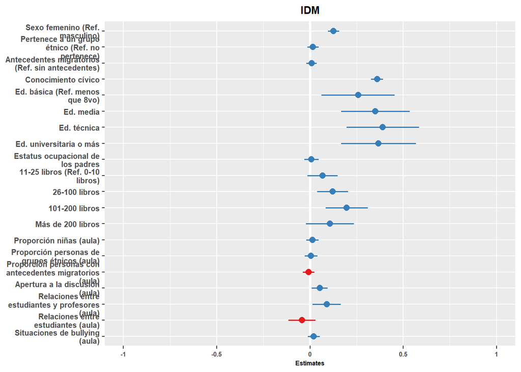

```r
########################
# gráfico
########################

modelo_gen <- sjPlot::plot_model(reg_gen, type=c("std"), axis.labels = c("Situaciones de bullying (aula)",
                                                                         "Relaciones entre estudiantes (aula)",
                                                                         "Relaciones entre estudiantes y profesores (aula)",
                                                                         "Apertura a la discusión (aula)",
                                                                         "Proporción personas con antecedentes migratorios (aula)",
                                                                          "Proporción personas de grupos étnicos (aula)",
                                                                        "Proporción niñas (aula)",
                                                                         "Más de 200 libros",
                                                                         "101-200 libros",
                                                                         "26-100 libros",
                                                                         "11-25 libros (Ref. 0-10 libros)",
                                                                         "Estatus ocupacional de los padres",
                                                                          "Ed. universitaria o más",
                                                                         "Ed. técnica",
                                                                         "Ed. media",
                                                                        "Ed. básica (Ref. menos que 8vo)",
                                                                         "Conocimiento cívico",
                                                                         "Antecedentes migratorios (Ref. sin antecedentes)",
                                                                         "Pertenece a un grupo étnico (Ref. no pertenece)",
                                                                         "Sexo femenino (Ref. masculino)"))  + ggtitle("IDM") + theme_grey() + theme(text=element_text(family="Times New Roman", face = "bold"), plot.title = element_text(size=10, hjust=0.5), axis.text.y = element_text(size=7.5), axis.title.x = element_text(size=6), axis.text.x = element_text(size=6))

#"Situaciones de bullying (grupal)",                                                                          "Situaciones de bullying (aula)",                                                                         "Relaciones entre estudiantes (grupal)",                                                                         "Relaciones entre estudiantes (aula)",                                                                         "Relaciones entre estudiantes y profesores (grupal)",             "Relaciones entre estudiantes y profesores (aula)",    "Apertura a la discusión (grupal)",                    "Apertura a la discusión (aula)",                                                                          "Proporción personas con antecedentes migratorios (aula)",                                                                           "Proporción personas de grupos étnicos (aula)",                                                                        "Proporción niñas (aula)",                                                                         "Más de 200 libros",                                                                          "101-200 libros",                                                                          "26-100 libros",                                                                          "11-25 libros (Ref. 0-10 libros)",                                                                          "Estatus ocupacional de los padres",                                                                           "Ed. universitaria o más",                                                                         "Ed. técnica",                                                                         "Ed. media",                                                                         "Ed. básica (Ref. menos que 8vo)",                                                                          "Conocimiento cívico",                                                                          "Antecedentes migratorios (Ref. sin antecedentes)",                                                                          "Pertenece a un grupo étnico (Ref. no pertenece)",                                                                         "Sexo femenino (Ref. masculino)"))

#"Sexo femenino (Ref. masculino)",                                                                          "Pertenece a un grupo étnico (Ref. no pertenece)",                                                                        "Antecedentes migratorios (Ref. sin antecedentes)",                                                                          "Conocimiento cívico",                                                                          "Ed. básica (Ref. menos que 8vo)",                                                                          "Ed. media",                                                                          "Ed. técnica",                                                                          "Ed. universitaria o más",                                                                          "Estatus ocupacional de los padres",                                                                          "11-25 libros (Ref. 0-10 libros)",                                                                          "26-100 libros",                                                                          "101-200 libros",                                                                          "Más de 200 libros",                                                                          "Proporción niñas (aula)",                                                                          "Proporción personas de grupos étnicos (aula)",                                                                          "Proporción personas con antecedentes migratorios (aula)",                                                                          "Apertura a la discusión (aula)",                                                                          "Apertura a la discusión (grupal)",                                                                          "Relaciones entre estudiantes y profesores (aula)",                                                                          "Relaciones entre estudiantes y profesores (grupal)",                                                                                                  "Relaciones entre estudiantes (aula)",                                                                          "Relaciones entre estudiantes (grupal)",                                                                          "Situaciones de bullying (aula)",                                                                          "Situaciones de bullying (grupal)")

#"Situaciones de bullying (grupal)", "Situaciones de bullying (aula)", "Relaciones entre estudiantes (grupal)", "Relaciones entre estudiantes (aula)", "Relaciones entre estudiantes y profesores (grupal)", "Relaciones entre estudiantes y profesores (aula)", "Apertura a la discusión (grupal)", "Apertura a la discusión (aula)", "Proporción personas con antecedentes migratorios en el aula", "Proporción grupos étnicos en el aula", "Proporción niñas en el aula", "Más de 200 libros", "101-200 libros", "26-100 libros", "11-25 libros (Ref. 0-10 libros)", "Estatus ocupacional de los padres", "Ed. universitaria o más", "Ed. técnica", "Ed. media", "Ed. básica (Ref. menos que 8vo)", "Pertenece a un grupo étnico (Ref. no pertenece)", "Antecedentes migratorios (Ref. sin antecedentes)", "Sexo femenino (Ref. masculino)","Conocimiento cívico"
modelo_gen
```

```r
ggsave(modelo_gen, filename = "../output/modelo_gen.png",device = "png",width = 18,height = 14.5,dpi = "retina",units = "cm")
```

### Igualdad de derechos para todos los grupos étnicos

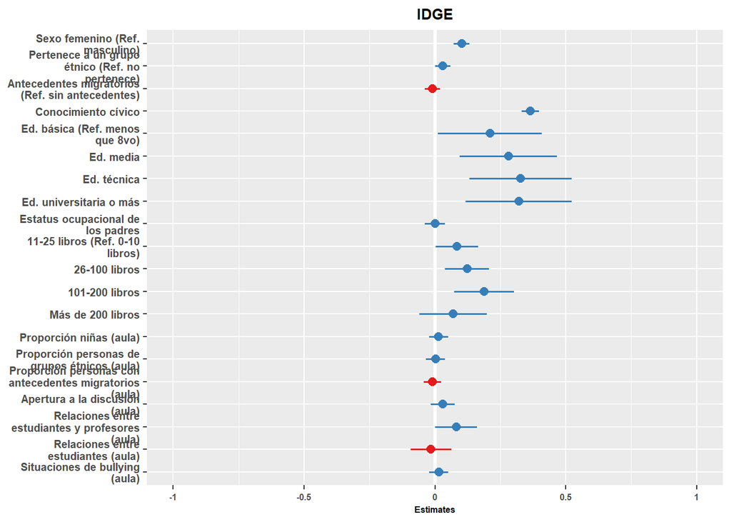

```r
########################
# gráfico
########################

modelo_etn0 <- sjPlot::plot_model(reg_etn, type=c("std"), axis.labels = c("Situaciones de bullying (aula)",
                                                                         "Relaciones entre estudiantes (aula)",
                                                                         "Relaciones entre estudiantes y profesores (aula)",
                                                                         "Apertura a la discusión (aula)",
                                                                         "Proporción personas con antecedentes migratorios (aula)",
                                                                          "Proporción personas de grupos étnicos (aula)",
                                                                        "Proporción niñas (aula)",
                                                                         "Más de 200 libros",
                                                                         "101-200 libros",
                                                                         "26-100 libros",
                                                                         "11-25 libros (Ref. 0-10 libros)",
                                                                         "Estatus ocupacional de los padres",
                                                                          "Ed. universitaria o más",
                                                                         "Ed. técnica",
                                                                         "Ed. media",
                                                                        "Ed. básica (Ref. menos que 8vo)",
                                                                         "Conocimiento cívico",
                                                                         "Antecedentes migratorios (Ref. sin antecedentes)",
                                                                         "Pertenece a un grupo étnico (Ref. no pertenece)",
                                                                         "Sexo femenino (Ref. masculino)"))  + ggtitle("IDGE") + theme_grey()+ theme(text=element_text(family="Times New Roman", face = "bold"), plot.title = element_text(size=10, hjust=0.5), axis.text.y = element_text(size=7.5), axis.title.x = element_text(size=6), axis.text.x = element_text(size=6))

modelo_etn0
```

```r
ggsave(modelo_etn0, filename = "../output/modelo_etn.png",device = "png",width = 18,height = 14.5,dpi = "retina",units = "cm")

modelo_etn <- sjPlot::plot_model(reg_etn, type=c("std"), axis.labels = c(" ", " ", " ", " ", " ", " ", " ", " ", " ", " ", " ", " ", " ", " ", " ", " ", " ", " ", " ", " ", " ", " ", " "," ")) + ggtitle("IDGE") + theme_grey()+ theme(text=element_text(family="Times New Roman", face = "bold"), plot.title = element_text(size=10, hjust=0.5), axis.text.y = element_text(size=7.5), axis.title.x = element_text(size=6), axis.text.x = element_text(size=6))
```

### Igualdad de derechos para los homosexuales

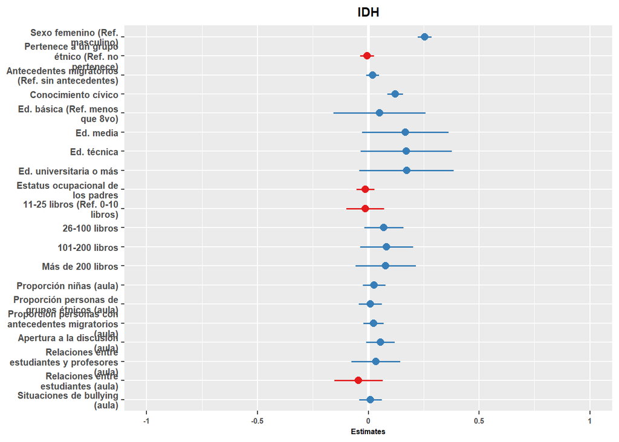

```r
########################
# gráfico
########################

modelo_hom0 <- sjPlot::plot_model(reg_hom, type=c("std"), axis.labels = c("Situaciones de bullying (aula)",
                                                                         "Relaciones entre estudiantes (aula)",
                                                                         "Relaciones entre estudiantes y profesores (aula)",
                                                                         "Apertura a la discusión (aula)",
                                                                         "Proporción personas con antecedentes migratorios (aula)",
                                                                          "Proporción personas de grupos étnicos (aula)",
                                                                        "Proporción niñas (aula)",
                                                                         "Más de 200 libros",
                                                                         "101-200 libros",
                                                                         "26-100 libros",
                                                                         "11-25 libros (Ref. 0-10 libros)",
                                                                         "Estatus ocupacional de los padres",
                                                                          "Ed. universitaria o más",
                                                                         "Ed. técnica",
                                                                         "Ed. media",
                                                                        "Ed. básica (Ref. menos que 8vo)",
                                                                         "Conocimiento cívico",
                                                                         "Antecedentes migratorios (Ref. sin antecedentes)",
                                                                         "Pertenece a un grupo étnico (Ref. no pertenece)",
                                                                         "Sexo femenino (Ref. masculino)"))  + ggtitle("IDH") + theme_grey() + theme(text=element_text(family="Times New Roman", face = "bold"), plot.title = element_text(size=10, hjust=0.5), axis.text.y = element_text(size=7.5), axis.title.x = element_text(size=6), axis.text.x = element_text(size=6))

modelo_hom0
```

```r
ggsave(modelo_hom0, filename = "../output/modelo_hom.png",device = "png",width = 18,height = 14.5,dpi = "retina",units = "cm")

modelo_hom <- sjPlot::plot_model(reg_hom, type=c("std"), axis.labels = c(" ", " ", " ", " ", " ", " ", " ", " ", " ", " ", " ", " ", " ", " ", " ", " ", " ", " ", " ", " ", " ", " ", " "," ")) + ggtitle("IDH") + theme_grey() + theme(text=element_text(family="Times New Roman", face = "bold"), plot.title = element_text(size=10, hjust=0.5), axis.text.y = element_text(size=7.5), axis.title.x = element_text(size=6), axis.text.x = element_text(size=6))
```

### Gráfico conjunto

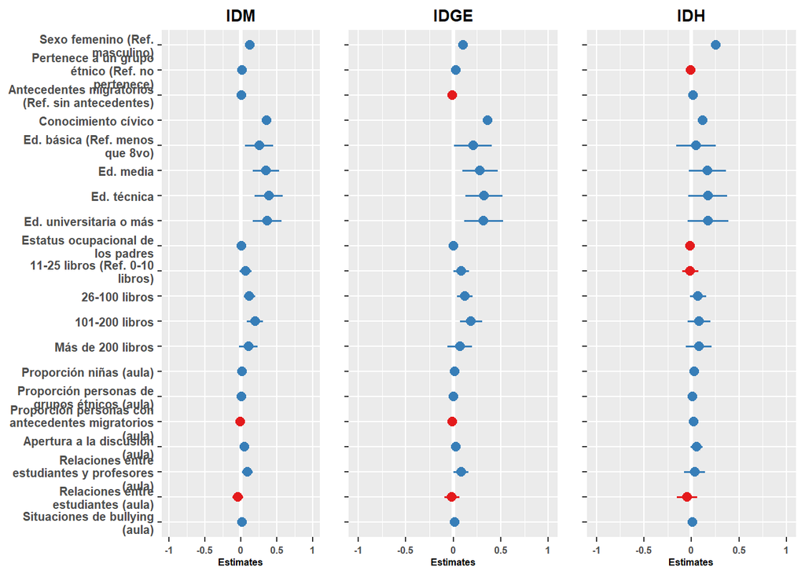

```r
general <- cowplot::plot_grid(modelo_gen,modelo_etn,modelo_hom, ncol=3, rel_widths = c(1.38, 1, 1))
general
```

```r
ggsave(general, file = "../output/graf_modelos_conjuntos.png",device = "png",width = 34,height = 18,dpi = "retina",units = "cm")
```

### Hipótesis 1.

*Hipótesis 1 (Hipótesis de desventaja): Pertenecer al sexo femenino, tener antecedentes migratorios y pertenecer a un grupo étnico son factores que tendrán una asociación positiva con las actitudes hacia la igualdad de derechos.*

#### Sexo

```r
reg_gen_1a <- lmer(f.genero ~ 1 +
                   sexo +
                   (1 | idschool), data=data_proc)

reg_etn_1a <- lmer(f.etnico ~ 1 +
                   sexo +
                   (1 | idschool), data=data_proc)

reg_hom_1a <- lmer(f.homosexual ~ 1 +
                   sexo +
                   (1 | idschool), data=data_proc)
```

```r
#screenreg(list(reg_gen_1a,reg_etn_1a,reg_hom_1a), custom.model.names = c("Igualdad de derechos entre hombres y mujeres", "Igualdad de derechos para todos los grupos étnicos", "Igualdad de derechos para los homosexuales"), custom.coef.names = c("Intercepto", "Sexo (Ref. Niño)"))

knitreg(list(reg_gen_1a,reg_etn_1a,reg_hom_1a), custom.model.names = c("Igualdad de derechos entre hombres y mujeres", "Igualdad de derechos para todos los grupos étnicos", "Igualdad de derechos para los homosexuales"), custom.coef.names = c("Intercepto", "Sexo <br> <i>(Ref. Niño)</i>"))
```

Statistical models

|  | Igualdad de derechos entre hombres y mujeres | Igualdad de derechos para todos los grupos étnicos | Igualdad de derechos para los homosexuales |
| --- | --- | --- | --- |
| Intercepto | -0.25*** | -0.24*** | -0.29*** |
|  | (0.02) | (0.02) | (0.02) |
| Sexo *(Ref. Niño)* | 0.21*** | 0.19*** | 0.40*** |
|  | (0.02) | (0.02) | (0.02) |
| AIC | 7265.36 | 7551.61 | 8369.10 |
| BIC | 7290.45 | 7576.71 | 8394.20 |
| Log Likelihood | -3628.68 | -3771.81 | -4180.55 |
| Num. obs. | 3920 | 3920 | 3920 |
| Num. groups: idschool | 166 | 166 | 166 |
| Var: idschool (Intercept) | 0.04 | 0.04 | 0.03 |
| Var: Residual | 0.35 | 0.38 | 0.47 |

***p < 0.001; **p < 0.01; *p < 0.05

```r
#, omit.coef = "(Educacion)|(Libros_apod_rec)|(quintiles_ingresos_pc_factor)|(igualdad.pad)|(esp_publico.pad)|(esp_privado.pad)|(ap_discusion)|(mean_discusion)|(num_fem)|(dependencia)|(REGION)|(c_civic)", custom.note = "$***p <$ 0.001, $**p <$ 0.01, $*p <$ 0.05 <br> Todos los modelos están controlados por el resto de las variables analizadas, la dependencia administrativa de la escuela, la región y el nivel de conocimiento cívico del estudiante."
```

#### Pertenencia a un grupo étnico

```r
reg_gen_1b <- lmer(f.genero ~ 1 +
                   etnico +
                   (1 | idschool), data=data_proc)

reg_etn_1b <- lmer(f.etnico ~ 1 +
                   etnico +
                   (1 | idschool), data=data_proc)

reg_hom_1b <- lmer(f.homosexual ~ 1 +
                   etnico +
                   (1 | idschool), data=data_proc)
```

```r
#screenreg(list(reg_gen_1b,reg_etn_1b,reg_hom_1b), custom.model.names = c("Igualdad de derechos entre hombres y mujeres", "Igualdad de derechos para todos los grupos étnicos", "Igualdad de derechos para los homosexuales"), custom.coef.names = c("Intercepto", "Pertenencer a un grupo étnico (Ref. no pertenencer)"))

knitreg(list(reg_gen_1b,reg_etn_1b,reg_hom_1b), custom.model.names = c("Igualdad de derechos entre hombres y mujeres", "Igualdad de derechos para todos los grupos étnicos", "Igualdad de derechos para los homosexuales"), custom.coef.names = c("Intercepto", "Pertenencer a un grupo étnico <br> <i>(Ref. no pertenencer)</i>"))
```

Statistical models

|  | Igualdad de derechos entre hombres y mujeres | Igualdad de derechos para todos los grupos étnicos | Igualdad de derechos para los homosexuales |
| --- | --- | --- | --- |
| Intercepto | -0.15*** | -0.15*** | -0.09*** |
|  | (0.02) | (0.02) | (0.02) |
| Pertenencer a un grupo étnico *(Ref. no pertenencer)* | 0.04 | 0.07 | -0.01 |
|  | (0.04) | (0.04) | (0.04) |
| AIC | 7372.85 | 7628.62 | 8664.97 |
| BIC | 7397.95 | 7653.72 | 8690.06 |
| Log Likelihood | -3682.43 | -3810.31 | -4328.48 |
| Num. obs. | 3920 | 3920 | 3920 |
| Num. groups: idschool | 166 | 166 | 166 |
| Var: idschool (Intercept) | 0.04 | 0.04 | 0.04 |
| Var: Residual | 0.36 | 0.39 | 0.51 |

***p < 0.001; **p < 0.01; *p < 0.05

#### Tener antecedentes migratorios

```r
reg_gen_1c <- lmer(f.genero ~ 1 +
                   migratorio +
                   (1 | idschool), data=data_proc)

reg_etn_1c <- lmer(f.etnico ~ 1 +
                   migratorio +
                   (1 | idschool), data=data_proc)

reg_hom_1c <- lmer(f.homosexual ~ 1 +
                   migratorio +
                   (1 | idschool), data=data_proc)
```

```r
#screenreg(list(reg_gen_1c,reg_etn_1c,reg_hom_1c), custom.model.names = c("Igualdad de derechos entre hombres y mujeres", "Igualdad de derechos para todos los grupos étnicos", "Igualdad de derechos para los homosexuales"), custom.coef.names = c("Intercepto", "Tener antecedentes migratorios (Ref. no tener)"))

knitreg(list(reg_gen_1c,reg_etn_1c,reg_hom_1c), custom.model.names = c("Igualdad de derechos entre hombres y mujeres", "Igualdad de derechos para todos los grupos étnicos", "Igualdad de derechos para los homosexuales"), custom.coef.names = c("Intercepto", "Tener antecedentes migratorios <br> <i>(Ref. no tener)</i>"))
```

Statistical models

|  | Igualdad de derechos entre hombres y mujeres | Igualdad de derechos para todos los grupos étnicos | Igualdad de derechos para los homosexuales |
| --- | --- | --- | --- |
| Intercepto | -0.23** | -0.15 | -0.20* |
|  | (0.07) | (0.08) | (0.09) |
| Tener antecedentes migratorios *(Ref. no tener)* | 0.08 | 0.01 | 0.11 |
|  | (0.07) | (0.08) | (0.09) |
| AIC | 7371.24 | 7630.30 | 8662.14 |
| BIC | 7396.33 | 7655.40 | 8687.23 |
| Log Likelihood | -3681.62 | -3811.15 | -4327.07 |
| Num. obs. | 3920 | 3920 | 3920 |
| Num. groups: idschool | 166 | 166 | 166 |
| Var: idschool (Intercept) | 0.04 | 0.04 | 0.04 |
| Var: Residual | 0.36 | 0.39 | 0.51 |

***p < 0.001; **p < 0.01; *p < 0.05

### Hipótesis 2.

*Hipótesis 2: El nivel de conocimiento cívico tendrá una asociación positiva con las actitudes hacia la igualdad de derechos.*

#### Conocimiento cívico

```r
reg_gen_2 <- lmer(f.genero ~ 1 +
                   c_civico +
                   (1 | idschool), data=data_proc)

reg_etn_2 <- lmer(f.etnico ~ 1 +
                   c_civico +
                   (1 | idschool), data=data_proc)

reg_hom_2 <- lmer(f.homosexual ~ 1 +
                   c_civico +
                   (1 | idschool), data=data_proc)
```

```r
#screenreg(list(reg_gen_2,reg_etn_2,reg_hom_2), custom.model.names = c("Igualdad de derechos entre hombres y mujeres", "Igualdad de derechos para todos los grupos étnicos", "Igualdad de derechos para los homosexuales"), custom.coef.names = c("Intercepto", "Conocimiento cívico"))

knitreg(list(reg_gen_2,reg_etn_2,reg_hom_2), custom.model.names = c("Igualdad de derechos entre hombres y mujeres", "Igualdad de derechos para todos los grupos étnicos", "Igualdad de derechos para los homosexuales"), custom.coef.names = c("Intercepto", "Conocimiento cívico"))
```

Statistical models

|  | Igualdad de derechos entre hombres y mujeres | Igualdad de derechos para todos los grupos étnicos | Igualdad de derechos para los homosexuales |
| --- | --- | --- | --- |
| Intercepto | -0.13*** | -0.13*** | -0.09*** |
|  | (0.01) | (0.01) | (0.02) |
| Conocimiento cívico | 0.26*** | 0.27*** | 0.13*** |
|  | (0.01) | (0.01) | (0.01) |
| AIC | 6764.42 | 7026.11 | 8574.28 |
| BIC | 6789.51 | 7051.20 | 8599.38 |
| Log Likelihood | -3378.21 | -3509.05 | -4283.14 |
| Num. obs. | 3920 | 3920 | 3920 |
| Num. groups: idschool | 166 | 166 | 166 |
| Var: idschool (Intercept) | 0.01 | 0.01 | 0.04 |
| Var: Residual | 0.32 | 0.34 | 0.50 |

***p < 0.001; **p < 0.01; *p < 0.05

### Hipótesis 3.

*Hipótesis 3 (Hipótesis de transmisión intergeneracional de la desigualdad en la socialización política): Los recursos socioeconómicos de la familia del estudiante (cantidad de libros en el hogar, estatus ocupacional de los padres y/o nivel educativo de los padres) se asociarán positivamente con las actitudes hacia la igualdad de derechos.*

#### Educación

```r
reg_gen_3a <- lmer(f.genero ~ 1 +
                   factor(educ_apod) +
                   (1 | idschool), data=data_proc)

reg_etn_3a <- lmer(f.etnico ~ 1 +
                   factor(educ_apod) +
                   (1 | idschool), data=data_proc)

reg_hom_3a <- lmer(f.homosexual ~ 1 +
                   factor(educ_apod) +
                   (1 | idschool), data=data_proc)
```

```r
#screenreg(list(reg_gen_3a,reg_etn_3a,reg_hom_3a), custom.model.names = c("Igualdad de derechos entre hombres y mujeres", "Igualdad de derechos para todos los grupos étnicos", "Igualdad de derechos para los homosexuales"), custom.coef.names = c("Intercepto", "Ed. básica (Ref. menos que 8vo)", "Ed. media", "Ed. técnica", "Ed. universitaria o más"))

knitreg(list(reg_gen_3a,reg_etn_3a,reg_hom_3a), custom.model.names = c("Igualdad de derechos entre hombres y mujeres", "Igualdad de derechos para todos los grupos étnicos", "Igualdad de derechos para los homosexuales"), custom.coef.names = c("Intercepto", "Ed. básica (Ref. menos que 8vo)", "Ed. media", "Ed. técnica", "Ed. universitaria o más"))
```

Statistical models

|  | Igualdad de derechos entre hombres y mujeres | Igualdad de derechos para todos los grupos étnicos | Igualdad de derechos para los homosexuales |
| --- | --- | --- | --- |
| Intercepto | -0.51*** | -0.48*** | -0.27*** |
|  | (0.06) | (0.07) | (0.08) |
| Ed. básica (Ref. menos que 8vo) | 0.23*** | 0.20** | 0.08 |
|  | (0.07) | (0.07) | (0.08) |
| Ed. media | 0.32*** | 0.29*** | 0.17* |
|  | (0.06) | (0.07) | (0.08) |
| Ed. técnica | 0.42*** | 0.39*** | 0.19* |
|  | (0.07) | (0.07) | (0.08) |
| Ed. universitaria o más | 0.48*** | 0.46*** | 0.22** |
|  | (0.07) | (0.07) | (0.08) |
| AIC | 7320.34 | 7581.12 | 8671.45 |
| BIC | 7364.25 | 7625.04 | 8715.37 |
| Log Likelihood | -3653.17 | -3783.56 | -4328.72 |
| Num. obs. | 3920 | 3920 | 3920 |
| Num. groups: idschool | 166 | 166 | 166 |
| Var: idschool (Intercept) | 0.02 | 0.02 | 0.04 |
| Var: Residual | 0.36 | 0.39 | 0.51 |

***p < 0.001; **p < 0.01; *p < 0.05

#### Estatus ocupacional

```r
reg_gen_3b <- lmer(f.genero ~ 1 +
                   ocup_apod +
                   (1 | idschool), data=data_proc)

reg_etn_3b <- lmer(f.etnico ~ 1 +
                   ocup_apod +
                   (1 | idschool), data=data_proc)

reg_hom_3b <- lmer(f.homosexual ~ 1 +
                   ocup_apod +
                   (1 | idschool), data=data_proc)
```

```r
#screenreg(list(reg_gen_3b,reg_etn_3b,reg_hom_3b), custom.model.names = c("Igualdad de derechos entre hombres y mujeres", "Igualdad de derechos para todos los grupos étnicos", "Igualdad de derechos para los homosexuales"), custom.coef.names = c("Intercepto", "Estatus ocupacional de los padres"))

knitreg(list(reg_gen_3b,reg_etn_3b,reg_hom_3b), custom.model.names = c("Igualdad de derechos entre hombres y mujeres", "Igualdad de derechos para todos los grupos étnicos", "Igualdad de derechos para los homosexuales"), custom.coef.names = c("Intercepto", "Estatus ocupacional de los padres"))
```

Statistical models

|  | Igualdad de derechos entre hombres y mujeres | Igualdad de derechos para todos los grupos étnicos | Igualdad de derechos para los homosexuales |
| --- | --- | --- | --- |
| Intercepto | -0.35*** | -0.35*** | -0.15*** |
|  | (0.03) | (0.03) | (0.04) |
| Estatus ocupacional de los padres | 0.00*** | 0.00*** | 0.00 |
|  | (0.00) | (0.00) | (0.00) |
| AIC | 7336.74 | 7596.01 | 8670.05 |
| BIC | 7361.84 | 7621.11 | 8695.14 |
| Log Likelihood | -3664.37 | -3794.01 | -4331.02 |
| Num. obs. | 3920 | 3920 | 3920 |
| Num. groups: idschool | 166 | 166 | 166 |
| Var: idschool (Intercept) | 0.03 | 0.03 | 0.04 |
| Var: Residual | 0.36 | 0.39 | 0.51 |

***p < 0.001; **p < 0.01; *p < 0.05

#### Cantidad de libros en el hogar

```r
reg_gen_3c <- lmer(f.genero ~ 1 +
                   factor(libros) +
                   (1 | idschool), data=data_proc)

reg_etn_3c <- lmer(f.etnico ~ 1 +
                   factor(libros) +
                   (1 | idschool), data=data_proc)

reg_hom_3c <- lmer(f.homosexual ~ 1 +
                   factor(libros) +
                   (1 | idschool), data=data_proc)
```

```r
#screenreg(list(reg_gen_3c,reg_etn_3c,reg_hom_3c), custom.model.names = c("Igualdad de derechos entre hombres y mujeres", "Igualdad de derechos para todos los grupos étnicos", "Igualdad de derechos para los homosexuales"), custom.coef.names = c("Intercepto", "11-25 libros (Ref. 0-10 libros)", "26-100 libros", "101-200 libros", "Más de 200 libros"))

knitreg(list(reg_gen_3c,reg_etn_3c,reg_hom_3c), custom.model.names = c("Igualdad de derechos entre hombres y mujeres", "Igualdad de derechos para todos los grupos étnicos", "Igualdad de derechos para los homosexuales"), custom.coef.names = c("Intercepto", "11-25 libros (Ref. 0-10 libros)", "26-100 libros", "101-200 libros", "Más de 200 libros"))
```

Statistical models

|  | Igualdad de derechos entre hombres y mujeres | Igualdad de derechos para todos los grupos étnicos | Igualdad de derechos para los homosexuales |
| --- | --- | --- | --- |
| Intercepto | -0.29*** | -0.29*** | -0.16*** |
|  | (0.03) | (0.03) | (0.03) |
| 11-25 libros (Ref. 0-10 libros) | 0.11*** | 0.13*** | 0.02 |
|  | (0.03) | (0.03) | (0.03) |
| 26-100 libros | 0.22*** | 0.23*** | 0.13*** |
|  | (0.03) | (0.03) | (0.03) |
| 101-200 libros | 0.30*** | 0.30*** | 0.15** |
|  | (0.04) | (0.04) | (0.05) |
| Más de 200 libros | 0.25*** | 0.23*** | 0.14** |
|  | (0.04) | (0.04) | (0.05) |
| AIC | 7311.69 | 7575.40 | 8659.11 |
| BIC | 7355.61 | 7619.32 | 8703.03 |
| Log Likelihood | -3648.85 | -3780.70 | -4322.56 |
| Num. obs. | 3920 | 3920 | 3920 |
| Num. groups: idschool | 166 | 166 | 166 |
| Var: idschool (Intercept) | 0.03 | 0.03 | 0.04 |
| Var: Residual | 0.36 | 0.38 | 0.51 |

***p < 0.001; **p < 0.01; *p < 0.05

### Hipótesis 4.

*Hipótesis 4 (Hipótesis de composición del aula): En relación con este punto, se sostendrán tres hipótesis: (a) la proporción de estudiantes en el aula pertenecientes al sexo femenino posee una asociación positiva con las actitudes hacia la igualdad de derechos, (b) la proporción de estudiantes en el aula pertenecientes a un grupo étnico posee una asociación positiva con las actitudes hacia la igualdad de derechos, y (c) la proporción de estudiantes en el aula que posean antecedentes migratorios tendrá una asociación positiva con las actitudes hacia la igualdad de derechos.*

#### Proporción de niñas en el aula

```r
reg_gen_4a <- lmer(f.genero ~ 1 +
                   num_fem +
                   (1 | idschool), data=data_proc)

reg_etn_4a <- lmer(f.etnico ~ 1 +
                   num_fem +
                   (1 | idschool), data=data_proc)

reg_hom_4a <- lmer(f.homosexual ~ 1 +
                   num_fem +
                   (1 | idschool), data=data_proc)
```

```r
screenreg(list(reg_gen_4a,reg_etn_4a,reg_hom_4a), custom.model.names = c("Igualdad de derechos entre hombres y mujeres", "Igualdad de derechos para todos los grupos étnicos", "Igualdad de derechos para los homosexuales"), custom.coef.names = c("Intercepto", "Proporción de niñas en el aula"))
```

[output not shown]

```r
knitreg(list(reg_gen_4a,reg_etn_4a,reg_hom_4a), custom.model.names = c("Igualdad de derechos entre hombres y mujeres", "Igualdad de derechos para todos los grupos étnicos", "Igualdad de derechos para los homosexuales"), custom.coef.names = c("Intercepto", "Proporción de niñas en el aula"))
```

Statistical models

|  | Igualdad de derechos entre hombres y mujeres | Igualdad de derechos para todos los grupos étnicos | Igualdad de derechos para los homosexuales |
| --- | --- | --- | --- |
| Intercepto | -0.30*** | -0.29*** | -0.36*** |
|  | (0.05) | (0.06) | (0.06) |
| Proporción de niñas en el aula | 0.32** | 0.31** | 0.55*** |
|  | (0.10) | (0.11) | (0.11) |
| AIC | 7362.56 | 7621.54 | 8638.77 |
| BIC | 7387.65 | 7646.63 | 8663.87 |
| Log Likelihood | -3677.28 | -3806.77 | -4315.39 |
| Num. obs. | 3920 | 3920 | 3920 |
| Num. groups: idschool | 166 | 166 | 166 |
| Var: idschool (Intercept) | 0.04 | 0.04 | 0.03 |
| Var: Residual | 0.36 | 0.39 | 0.51 |

***p < 0.001; **p < 0.01; *p < 0.05

## Pendientes fijas y aleatorias

#### Igualdad de derechos entre hombres y mujeres

```r
reg_gen <- lmer(f.genero ~ 1 +
                   sexo +
                   etnico +
                   migratorio +
                   c_civico +
                   factor(educ_apod) +
                   ocup_apod +
                   factor(libros) +
                   num_fem +
                   num_etn +
                   num_mig +
                   f.ap_discusion +
                   mean_discusion +
                   f.buen_clima_prof +
                   mean_bclima_prof +
                   f.buen_clima_est +
                   mean_bclima_est +
                   f.mal_clima +
                  mean_mal_clima +
                   (1 | idschool), data=data_proc)
```

```
## Error in eval(predvars, data, env): objeto 'f.ap_discusion' no encontrado
```

```r
# Sexo
reg_gen_1a <- lmer(f.genero ~ 1 +
                   sexo +
                   etnico +
                   migratorio +
                   c_civico +
                   factor(educ_apod) +
                   ocup_apod +
                   factor(libros) +
                   num_fem +
                   num_etn +
                   num_mig +
                   f.ap_discusion +
                   mean_discusion +
                   f.buen_clima_prof +
                   mean_bclima_prof +
                   f.buen_clima_est +
                   mean_bclima_est +
                   f.mal_clima +
                     mean_mal_clima +
                   (1 + sexo | idschool), data=data_proc)
```

```
## Error in eval(predvars, data, env): objeto 'f.ap_discusion' no encontrado
```

```r
anova(reg_gen,reg_gen_1a) #sí hay diferencias significativas (aic es menor en el 2do modelo, bic es un poco mayor en el 2do)
```

```
## Data: data_proc
## Models:
## reg_gen_1a: f.genero ~ 1 + sexo + (1 | idschool)
## reg_gen: f.genero ~ 1 + sexo + etnico + migratorio + c_civico + factor(educ_apod) + ocup_apod + factor(libros) + num_fem + num_etn + num_mig + f.ap_discusion_aula + f.buen_clima_prof_aula + f.buen_clima_est_aula + f.mal_clima_aula + (1 | idschool)
##            npar    AIC    BIC  logLik deviance  Chisq Df Pr(>Chisq)
## reg_gen_1a    4 7253.2 7278.3 -3622.6   7245.2
## reg_gen      23 6632.1 6776.4 -3293.0   6586.1 659.11 19  < 2.2e-16 ***
## ---
## Signif. codes:  0 '***' 0.001 '**' 0.01 '*' 0.05 '.' 0.1 ' ' 1
```

```r
# Grupo étnico
reg_gen_1b <- lmer(f.genero ~ 1 +
                   sexo +
                   etnico +
                   migratorio +
                   c_civico +
                   factor(educ_apod) +
                   ocup_apod +
                   factor(libros) +
                   num_fem +
                   num_etn +
                   num_mig +
                   f.ap_discusion +
                   mean_discusion +
                   f.buen_clima_prof +
                   mean_bclima_prof +
                   f.buen_clima_est +
                   mean_bclima_est +
                   f.mal_clima +
                     mean_mal_clima +
                   (1 + etnico | idschool), data=data_proc)
```

```
## Error in eval(predvars, data, env): objeto 'f.ap_discusion' no encontrado
```

```r
anova(reg_gen,reg_gen_1b) #no
```

```
## Data: data_proc
## Models:
## reg_gen_1b: f.genero ~ 1 + etnico + (1 | idschool)
## reg_gen: f.genero ~ 1 + sexo + etnico + migratorio + c_civico + factor(educ_apod) + ocup_apod + factor(libros) + num_fem + num_etn + num_mig + f.ap_discusion_aula + f.buen_clima_prof_aula + f.buen_clima_est_aula + f.mal_clima_aula + (1 | idschool)
##            npar    AIC    BIC logLik deviance  Chisq Df Pr(>Chisq)
## reg_gen_1b    4 7361.9 7387.0  -3677   7353.9
## reg_gen      23 6632.1 6776.4  -3293   6586.1 767.89 19  < 2.2e-16 ***
## ---
## Signif. codes:  0 '***' 0.001 '**' 0.01 '*' 0.05 '.' 0.1 ' ' 1
```

```r
# Antecedentes migratorios
reg_gen_1c <- lmer(f.genero ~ 1 +
                   sexo +
                   etnico +
                   migratorio +
                   c_civico +
                   factor(educ_apod) +
                   ocup_apod +
                   factor(libros) +
                   num_fem +
                   num_etn +
                   num_mig +
                   f.ap_discusion +
                   mean_discusion +
                   f.buen_clima_prof +
                   mean_bclima_prof +
                   f.buen_clima_est +
                   mean_bclima_est +
                   f.mal_clima +
                     mean_mal_clima +
                   (1 + migratorio | idschool), data=data_proc)
```

```
## Error in eval(predvars, data, env): objeto 'f.ap_discusion' no encontrado
```

```r
anova(reg_gen,reg_gen_1c) #no
```

```
## Data: data_proc
## Models:
## reg_gen_1c: f.genero ~ 1 + migratorio + (1 | idschool)
## reg_gen: f.genero ~ 1 + sexo + etnico + migratorio + c_civico + factor(educ_apod) + ocup_apod + factor(libros) + num_fem + num_etn + num_mig + f.ap_discusion_aula + f.buen_clima_prof_aula + f.buen_clima_est_aula + f.mal_clima_aula + (1 | idschool)
##            npar    AIC    BIC  logLik deviance  Chisq Df Pr(>Chisq)
## reg_gen_1c    4 7361.7 7386.8 -3676.8   7353.7
## reg_gen      23 6632.1 6776.4 -3293.0   6586.1 767.65 19  < 2.2e-16 ***
## ---
## Signif. codes:  0 '***' 0.001 '**' 0.01 '*' 0.05 '.' 0.1 ' ' 1
```

```r
# Conocimiento cívico
reg_gen_2 <- lmer(f.genero ~ 1 +
                   sexo +
                   etnico +
                   migratorio +
                   c_civico +
                   factor(educ_apod) +
                   ocup_apod +
                   factor(libros) +
                   num_fem +
                   num_etn +
                   num_mig +
                   f.ap_discusion +
                   mean_discusion +
                   f.buen_clima_prof +
                   mean_bclima_prof +
                   f.buen_clima_est +
                   mean_bclima_est +
                   f.mal_clima +
                    mean_mal_clima +
                   (1 + c_civico | idschool), data=data_proc)
```

```
## Error in eval(predvars, data, env): objeto 'f.ap_discusion' no encontrado
```

```r
anova(reg_gen,reg_gen_2) #sí hay diferencias significativas (aic es menor en el 2do modelo, bic es un poco mayor en el 2do)
```

```
## Data: data_proc
## Models:
## reg_gen_2: f.genero ~ 1 + c_civico + (1 | idschool)
## reg_gen: f.genero ~ 1 + sexo + etnico + migratorio + c_civico + factor(educ_apod) + ocup_apod + factor(libros) + num_fem + num_etn + num_mig + f.ap_discusion_aula + f.buen_clima_prof_aula + f.buen_clima_est_aula + f.mal_clima_aula + (1 | idschool)
##           npar    AIC    BIC  logLik deviance  Chisq Df Pr(>Chisq)
## reg_gen_2    4 6749.8 6774.9 -3370.9   6741.8
## reg_gen     23 6632.1 6776.4 -3293.0   6586.1 155.76 19  < 2.2e-16 ***
## ---
## Signif. codes:  0 '***' 0.001 '**' 0.01 '*' 0.05 '.' 0.1 ' ' 1
```

```r
# Educación de los padres
reg_gen_3a <- lmer(f.genero ~ 1 +
                   sexo +
                   etnico +
                   migratorio +
                   c_civico +
                   factor(educ_apod) +
                   ocup_apod +
                   factor(libros) +
                   num_fem +
                   num_etn +
                   num_mig +
                   f.ap_discusion +
                   mean_discusion +
                   f.buen_clima_prof +
                   mean_bclima_prof +
                   f.buen_clima_est +
                   mean_bclima_est +
                   f.mal_clima +
                     mean_mal_clima+
                   (1 + factor(educ_apod) | idschool), data=data_proc)
```

```
## Error in eval(predvars, data, env): objeto 'f.ap_discusion' no encontrado
```

```r
anova(reg_gen,reg_gen_3a) #no
```

```
## Data: data_proc
## Models:
## reg_gen_3a: f.genero ~ 1 + factor(educ_apod) + (1 | idschool)
## reg_gen: f.genero ~ 1 + sexo + etnico + migratorio + c_civico + factor(educ_apod) + ocup_apod + factor(libros) + num_fem + num_etn + num_mig + f.ap_discusion_aula + f.buen_clima_prof_aula + f.buen_clima_est_aula + f.mal_clima_aula + (1 | idschool)
##            npar    AIC    BIC  logLik deviance  Chisq Df Pr(>Chisq)
## reg_gen_3a    7 7294.3 7338.2 -3640.1   7280.3
## reg_gen      23 6632.1 6776.4 -3293.0   6586.1 694.22 16  < 2.2e-16 ***
## ---
## Signif. codes:  0 '***' 0.001 '**' 0.01 '*' 0.05 '.' 0.1 ' ' 1
```

```r
# Estatus ocupacional
reg_gen_3b <- lmer(f.genero ~ 1 +
                   sexo +
                   etnico +
                   migratorio +
                   c_civico +
                   factor(educ_apod) +
                   ocup_apod +
                   factor(libros) +
                   num_fem +
                   num_etn +
                   num_mig +
                   f.ap_discusion +
                   mean_discusion +
                   f.buen_clima_prof +
                   mean_bclima_prof +
                   f.buen_clima_est +
                   mean_bclima_est +
                   f.mal_clima +
                     mean_mal_clima +
                   (1 + ocup_apod | idschool), data=data_proc)
```

```
## Error in eval(predvars, data, env): objeto 'f.ap_discusion' no encontrado
```

```r
anova(reg_gen,reg_gen_3b) #no
```

```
## Data: data_proc
## Models:
## reg_gen_3b: f.genero ~ 1 + ocup_apod + (1 | idschool)
## reg_gen: f.genero ~ 1 + sexo + etnico + migratorio + c_civico + factor(educ_apod) + ocup_apod + factor(libros) + num_fem + num_etn + num_mig + f.ap_discusion_aula + f.buen_clima_prof_aula + f.buen_clima_est_aula + f.mal_clima_aula + (1 | idschool)
##            npar    AIC    BIC  logLik deviance Chisq Df Pr(>Chisq)
## reg_gen_3b    4 7317.5 7342.5 -3654.7   7309.5
## reg_gen      23 6632.1 6776.4 -3293.0   6586.1 723.4 19  < 2.2e-16 ***
## ---
## Signif. codes:  0 '***' 0.001 '**' 0.01 '*' 0.05 '.' 0.1 ' ' 1
```

```r
# Cantidad de libros en el hogar
reg_gen_3c <- lmer(f.genero ~ 1 +
                   sexo +
                   etnico +
                   migratorio +
                   c_civico +
                   factor(educ_apod) +
                   ocup_apod +
                   factor(libros) +
                   num_fem +
                   num_etn +
                   num_mig +
                   f.ap_discusion +
                   mean_discusion +
                   f.buen_clima_prof +
                   mean_bclima_prof +
                   f.buen_clima_est +
                   mean_bclima_est +
                   f.mal_clima +
                     mean_mal_clima +
                   (1 + factor(libros) | idschool), data=data_proc)
```

```
## Error in eval(predvars, data, env): objeto 'f.ap_discusion' no encontrado
```

```r
anova(reg_gen,reg_gen_3c) #no
```

```
## Data: data_proc
## Models:
## reg_gen_3c: f.genero ~ 1 + factor(libros) + (1 | idschool)
## reg_gen: f.genero ~ 1 + sexo + etnico + migratorio + c_civico + factor(educ_apod) + ocup_apod + factor(libros) + num_fem + num_etn + num_mig + f.ap_discusion_aula + f.buen_clima_prof_aula + f.buen_clima_est_aula + f.mal_clima_aula + (1 | idschool)
##            npar    AIC    BIC  logLik deviance Chisq Df Pr(>Chisq)
## reg_gen_3c    7 7284.5 7328.5 -3635.3   7270.5
## reg_gen      23 6632.1 6776.4 -3293.0   6586.1 684.5 16  < 2.2e-16 ***
## ---
## Signif. codes:  0 '***' 0.001 '**' 0.01 '*' 0.05 '.' 0.1 ' ' 1
```

#### Igualdad de derechos para todos los grupos étnicos

```r
reg_etn <- lmer(f.etnico ~ 1 +
                   sexo +
                   etnico +
                   migratorio +
                   c_civico +
                   factor(educ_apod) +
                   ocup_apod +
                   factor(libros) +
                   num_fem +
                   num_etn +
                   num_mig +
                   f.ap_discusion +
                   mean_discusion +
                   f.buen_clima_prof +
                   mean_bclima_prof +
                   f.buen_clima_est +
                   mean_bclima_est +
                   f.mal_clima +
                  mean_mal_clima +
                  (1 | idschool), data=data_proc)
```

```
## Error in eval(predvars, data, env): objeto 'f.ap_discusion' no encontrado
```

```r
# Sexo
reg_etn_1a <- lmer(f.etnico ~ 1 +
                   sexo +
                   etnico +
                   migratorio +
                   c_civico +
                   factor(educ_apod) +
                   ocup_apod +
                   factor(libros) +
                   num_fem +
                   num_etn +
                   num_mig +
                   f.ap_discusion +
                   mean_discusion +
                   f.buen_clima_prof +
                   mean_bclima_prof +
                   f.buen_clima_est +
                   mean_bclima_est +
                   f.mal_clima +
                     mean_mal_clima+
                   (1 + sexo | idschool), data=data_proc)
```

```
## Error in eval(predvars, data, env): objeto 'f.ap_discusion' no encontrado
```

```r
anova(reg_etn,reg_etn_1a) #sí hay diferencias significativas (aic es menor en el 2do modelo, bic es un poco mayor en el 2do)
```

```
## Data: data_proc
## Models:
## reg_etn_1a: f.etnico ~ 1 + sexo + (1 | idschool)
## reg_etn: f.etnico ~ 1 + sexo + etnico + migratorio + c_civico + factor(educ_apod) + ocup_apod + factor(libros) + num_fem + num_etn + num_mig + f.ap_discusion_aula + f.buen_clima_prof_aula + f.buen_clima_est_aula + f.mal_clima_aula + (1 | idschool)
##            npar    AIC    BIC  logLik deviance  Chisq Df Pr(>Chisq)
## reg_etn_1a    4 7539.5 7564.6 -3765.8   7531.5
## reg_etn      23 6933.4 7077.7 -3443.7   6887.4 644.12 19  < 2.2e-16 ***
## ---
## Signif. codes:  0 '***' 0.001 '**' 0.01 '*' 0.05 '.' 0.1 ' ' 1
```

```r
# Grupo étnico
reg_etn_1b <- lmer(f.etnico ~ 1 +
                   sexo +
                   etnico +
                   migratorio +
                   c_civico +
                   factor(educ_apod) +
                   ocup_apod +
                   factor(libros) +
                   num_fem +
                   num_etn +
                   num_mig +
                   f.ap_discusion +
                   mean_discusion +
                   f.buen_clima_prof +
                   mean_bclima_prof +
                   f.buen_clima_est +
                   mean_bclima_est +
                   f.mal_clima +
                     mean_mal_clima +
                   (1 + etnico | idschool), data=data_proc)
```

```
## Error in eval(predvars, data, env): objeto 'f.ap_discusion' no encontrado
```

```r
anova(reg_etn,reg_etn_1b) #no
```

```
## Data: data_proc
## Models:
## reg_etn_1b: f.etnico ~ 1 + etnico + (1 | idschool)
## reg_etn: f.etnico ~ 1 + sexo + etnico + migratorio + c_civico + factor(educ_apod) + ocup_apod + factor(libros) + num_fem + num_etn + num_mig + f.ap_discusion_aula + f.buen_clima_prof_aula + f.buen_clima_est_aula + f.mal_clima_aula + (1 | idschool)
##            npar    AIC    BIC  logLik deviance Chisq Df Pr(>Chisq)
## reg_etn_1b    4 7617.8 7642.9 -3804.9   7609.8
## reg_etn      23 6933.4 7077.7 -3443.7   6887.4 722.4 19  < 2.2e-16 ***
## ---
## Signif. codes:  0 '***' 0.001 '**' 0.01 '*' 0.05 '.' 0.1 ' ' 1
```

```r
# Antecedentes migratorios
reg_etn_1c <- lmer(f.etnico ~ 1 +
                   sexo +
                   etnico +
                   migratorio +
                   c_civico +
                   factor(educ_apod) +
                   ocup_apod +
                   factor(libros) +
                   num_fem +
                   num_etn +
                   num_mig +
                   f.ap_discusion +
                   mean_discusion +
                   f.buen_clima_prof +
                   mean_bclima_prof +
                   f.buen_clima_est +
                   mean_bclima_est +
                   f.mal_clima +
                     mean_mal_clima+
                   (1 + migratorio | idschool), data=data_proc)
```

```
## Error in eval(predvars, data, env): objeto 'f.ap_discusion' no encontrado
```

```r
anova(reg_etn,reg_etn_1c) #no
```

```
## Data: data_proc
## Models:
## reg_etn_1c: f.etnico ~ 1 + migratorio + (1 | idschool)
## reg_etn: f.etnico ~ 1 + sexo + etnico + migratorio + c_civico + factor(educ_apod) + ocup_apod + factor(libros) + num_fem + num_etn + num_mig + f.ap_discusion_aula + f.buen_clima_prof_aula + f.buen_clima_est_aula + f.mal_clima_aula + (1 | idschool)
##            npar    AIC    BIC  logLik deviance  Chisq Df Pr(>Chisq)
## reg_etn_1c    4 7620.9 7646.0 -3806.4   7612.9
## reg_etn      23 6933.4 7077.7 -3443.7   6887.4 725.45 19  < 2.2e-16 ***
## ---
## Signif. codes:  0 '***' 0.001 '**' 0.01 '*' 0.05 '.' 0.1 ' ' 1
```

```r
# Conocimiento cívico
reg_etn_2 <- lmer(f.etnico ~ 1 +
                   sexo +
                   etnico +
                   migratorio +
                   c_civico +
                   factor(educ_apod) +
                   ocup_apod +
                   factor(libros) +
                   num_fem +
                   num_etn +
                   num_mig +
                   f.ap_discusion +
                   mean_discusion +
                   f.buen_clima_prof +
                   mean_bclima_prof +
                   f.buen_clima_est +
                   mean_bclima_est +
                   f.mal_clima +
                    mean_mal_clima+
                   (1 + c_civico | idschool), data=data_proc)
```

```
## Error in eval(predvars, data, env): objeto 'f.ap_discusion' no encontrado
```

```r
anova(reg_etn,reg_etn_2) #sí hay diferencias significativas (aic es menor en el 2do modelo, bic es muy poco mayor en el 2do)
```

```
## Data: data_proc
## Models:
## reg_etn_2: f.etnico ~ 1 + c_civico + (1 | idschool)
## reg_etn: f.etnico ~ 1 + sexo + etnico + migratorio + c_civico + factor(educ_apod) + ocup_apod + factor(libros) + num_fem + num_etn + num_mig + f.ap_discusion_aula + f.buen_clima_prof_aula + f.buen_clima_est_aula + f.mal_clima_aula + (1 | idschool)
##           npar    AIC    BIC  logLik deviance  Chisq Df Pr(>Chisq)
## reg_etn_2    4 7011.7 7036.8 -3501.9   7003.7
## reg_etn     23 6933.4 7077.7 -3443.7   6887.4 116.29 19  5.451e-16 ***
## ---
## Signif. codes:  0 '***' 0.001 '**' 0.01 '*' 0.05 '.' 0.1 ' ' 1
```

```r
# Educación de los padres
reg_etn_3a <- lmer(f.etnico ~ 1 +
                   sexo +
                   etnico +
                   migratorio +
                   c_civico +
                   factor(educ_apod) +
                   ocup_apod +
                   factor(libros) +
                   num_fem +
                   num_etn +
                   num_mig +
                   f.ap_discusion +
                   mean_discusion +
                   f.buen_clima_prof +
                   mean_bclima_prof +
                   f.buen_clima_est +
                   mean_bclima_est +
                   f.mal_clima +
                     mean_mal_clima +
                   (1 + factor(educ_apod) | idschool), data=data_proc)
```

```
## Error in eval(predvars, data, env): objeto 'f.ap_discusion' no encontrado
```

```r
anova(reg_etn,reg_etn_3a) #no
```

```
## Data: data_proc
## Models:
## reg_etn_3a: f.etnico ~ 1 + factor(educ_apod) + (1 | idschool)
## reg_etn: f.etnico ~ 1 + sexo + etnico + migratorio + c_civico + factor(educ_apod) + ocup_apod + factor(libros) + num_fem + num_etn + num_mig + f.ap_discusion_aula + f.buen_clima_prof_aula + f.buen_clima_est_aula + f.mal_clima_aula + (1 | idschool)
##            npar    AIC    BIC  logLik deviance  Chisq Df Pr(>Chisq)
## reg_etn_3a    7 7555.4 7599.3 -3770.7   7541.4
## reg_etn      23 6933.4 7077.7 -3443.7   6887.4 653.98 16  < 2.2e-16 ***
## ---
## Signif. codes:  0 '***' 0.001 '**' 0.01 '*' 0.05 '.' 0.1 ' ' 1
```

```r
# Estatus ocupacional
reg_etn_3b <- lmer(f.etnico ~ 1 +
                   sexo +
                   etnico +
                   migratorio +
                   c_civico +
                   factor(educ_apod) +
                   ocup_apod +
                   factor(libros) +
                   num_fem +
                   num_etn +
                   num_mig +
                   f.ap_discusion +
                   mean_discusion +
                   f.buen_clima_prof +
                   mean_bclima_prof +
                   f.buen_clima_est +
                   mean_bclima_est +
                   f.mal_clima +
                     mean_mal_clima +
                   (1 + ocup_apod | idschool), data=data_proc)
```

```
## Error in eval(predvars, data, env): objeto 'f.ap_discusion' no encontrado
```

```r
anova(reg_etn,reg_etn_3b) #no
```

```
## Data: data_proc
## Models:
## reg_etn_3b: f.etnico ~ 1 + ocup_apod + (1 | idschool)
## reg_etn: f.etnico ~ 1 + sexo + etnico + migratorio + c_civico + factor(educ_apod) + ocup_apod + factor(libros) + num_fem + num_etn + num_mig + f.ap_discusion_aula + f.buen_clima_prof_aula + f.buen_clima_est_aula + f.mal_clima_aula + (1 | idschool)
##            npar    AIC    BIC  logLik deviance  Chisq Df Pr(>Chisq)
## reg_etn_3b    4 7576.9 7602.0 -3784.4   7568.9
## reg_etn      23 6933.4 7077.7 -3443.7   6887.4 681.44 19  < 2.2e-16 ***
## ---
## Signif. codes:  0 '***' 0.001 '**' 0.01 '*' 0.05 '.' 0.1 ' ' 1
```

```r
# Cantidad de libros en el hogar
reg_etn_3c <- lmer(f.etnico ~ 1 +
                   sexo +
                   etnico +
                   migratorio +
                   c_civico +
                   factor(educ_apod) +
                   ocup_apod +
                   factor(libros) +
                   num_fem +
                   num_etn +
                   num_mig +
                   f.ap_discusion +
                   mean_discusion +
                   f.buen_clima_prof +
                   mean_bclima_prof +
                   f.buen_clima_est +
                   mean_bclima_est +
                   f.mal_clima +
                     mean_mal_clima+
                   (1 + factor(libros) | idschool), data=data_proc)
```

```
## Error in eval(predvars, data, env): objeto 'f.ap_discusion' no encontrado
```

```r
anova(reg_etn,reg_etn_3c) #no
```

```
## Data: data_proc
## Models:
## reg_etn_3c: f.etnico ~ 1 + factor(libros) + (1 | idschool)
## reg_etn: f.etnico ~ 1 + sexo + etnico + migratorio + c_civico + factor(educ_apod) + ocup_apod + factor(libros) + num_fem + num_etn + num_mig + f.ap_discusion_aula + f.buen_clima_prof_aula + f.buen_clima_est_aula + f.mal_clima_aula + (1 | idschool)
##            npar    AIC    BIC  logLik deviance  Chisq Df Pr(>Chisq)
## reg_etn_3c    7 7548.6 7592.5 -3767.3   7534.6
## reg_etn      23 6933.4 7077.7 -3443.7   6887.4 647.16 16  < 2.2e-16 ***
## ---
## Signif. codes:  0 '***' 0.001 '**' 0.01 '*' 0.05 '.' 0.1 ' ' 1
```

#### Igualdad de derechos para los homosexuales

```r
reg_hom <- lmer(f.homosexual ~ 1 +
                   sexo +
                   etnico +
                   migratorio +
                   c_civico +
                   factor(educ_apod) +
                   ocup_apod +
                   factor(libros) +
                   num_fem +
                   num_etn +
                   num_mig +
                   f.ap_discusion +
                   mean_discusion +
                   f.buen_clima_prof +
                   mean_bclima_prof +
                   f.buen_clima_est +
                   mean_bclima_est +
                   f.mal_clima +
                  mean_mal_clima +
                  (1 | idschool), data=data_proc)
```

```
## Error in eval(predvars, data, env): objeto 'f.ap_discusion' no encontrado
```

```r
# Sexo
reg_hom_1a <- lmer(f.homosexual ~ 1 +
                   sexo +
                   etnico +
                   migratorio +
                   c_civico +
                   factor(educ_apod) +
                   ocup_apod +
                   factor(libros) +
                   num_fem +
                   num_etn +
                   num_mig +
                   f.ap_discusion +
                   mean_discusion +
                   f.buen_clima_prof +
                   mean_bclima_prof +
                   f.buen_clima_est +
                   mean_bclima_est +
                   f.mal_clima +
                     mean_mal_clima+
                   (1 + sexo | idschool), data=data_proc)
```

```
## Error in eval(predvars, data, env): objeto 'f.ap_discusion' no encontrado
```

```r
anova(reg_hom,reg_hom_1a) #no
```

```
## Data: data_proc
## Models:
## reg_hom_1a: f.homosexual ~ 1 + sexo + (1 | idschool)
## reg_hom: f.homosexual ~ 1 + sexo + etnico + migratorio + c_civico + factor(educ_apod) + ocup_apod + factor(libros) + num_fem + num_etn + num_mig + f.ap_discusion_aula + f.buen_clima_prof_aula + f.buen_clima_est_aula + f.mal_clima_aula + (1 | idschool)
##            npar    AIC    BIC  logLik deviance  Chisq Df Pr(>Chisq)
## reg_hom_1a    4 8357.2 8382.3 -4174.6   8349.2
## reg_hom      23 8305.8 8450.1 -4129.9   8259.8 89.398 19  4.239e-11 ***
## ---
## Signif. codes:  0 '***' 0.001 '**' 0.01 '*' 0.05 '.' 0.1 ' ' 1
```

```r
# Grupo étnico
reg_hom_1b <- lmer(f.homosexual ~ 1 +
                   sexo +
                   etnico +
                   migratorio +
                   c_civico +
                   factor(educ_apod) +
                   ocup_apod +
                   factor(libros) +
                   num_fem +
                   num_etn +
                   num_mig +
                   f.ap_discusion +
                   mean_discusion +
                   f.buen_clima_prof +
                   mean_bclima_prof +
                   f.buen_clima_est +
                   mean_bclima_est +
                   f.mal_clima +
                     mean_mal_clima +
                   (1 + etnico | idschool), data=data_proc)
```

```
## Error in eval(predvars, data, env): objeto 'f.ap_discusion' no encontrado
```

```r
anova(reg_hom,reg_hom_1b) #no
```

```
## Data: data_proc
## Models:
## reg_hom_1b: f.homosexual ~ 1 + etnico + (1 | idschool)
## reg_hom: f.homosexual ~ 1 + sexo + etnico + migratorio + c_civico + factor(educ_apod) + ocup_apod + factor(libros) + num_fem + num_etn + num_mig + f.ap_discusion_aula + f.buen_clima_prof_aula + f.buen_clima_est_aula + f.mal_clima_aula + (1 | idschool)
##            npar    AIC    BIC  logLik deviance  Chisq Df Pr(>Chisq)
## reg_hom_1b    4 8654.5 8679.6 -4323.3   8646.5
## reg_hom      23 8305.8 8450.1 -4129.9   8259.8 386.68 19  < 2.2e-16 ***
## ---
## Signif. codes:  0 '***' 0.001 '**' 0.01 '*' 0.05 '.' 0.1 ' ' 1
```

```r
# Antecedentes migratorios
reg_hom_1c <- lmer(f.homosexual ~ 1 +
                   sexo +
                   etnico +
                   migratorio +
                   c_civico +
                   factor(educ_apod) +
                   ocup_apod +
                   factor(libros) +
                   num_fem +
                   num_etn +
                   num_mig +
                   f.ap_discusion +
                   mean_discusion +
                   f.buen_clima_prof +
                   mean_bclima_prof +
                   f.buen_clima_est +
                   mean_bclima_est +
                   f.mal_clima +
                     mean_mal_clima +
                   (1 + migratorio | idschool), data=data_proc)
```

```
## Error in eval(predvars, data, env): objeto 'f.ap_discusion' no encontrado
```

```r
anova(reg_hom,reg_hom_1c) #no
```

```
## Data: data_proc
## Models:
## reg_hom_1c: f.homosexual ~ 1 + migratorio + (1 | idschool)
## reg_hom: f.homosexual ~ 1 + sexo + etnico + migratorio + c_civico + factor(educ_apod) + ocup_apod + factor(libros) + num_fem + num_etn + num_mig + f.ap_discusion_aula + f.buen_clima_prof_aula + f.buen_clima_est_aula + f.mal_clima_aula + (1 | idschool)
##            npar    AIC    BIC  logLik deviance  Chisq Df Pr(>Chisq)
## reg_hom_1c    4 8653.1 8678.2 -4322.5   8645.1
## reg_hom      23 8305.8 8450.1 -4129.9   8259.8 385.24 19  < 2.2e-16 ***
## ---
## Signif. codes:  0 '***' 0.001 '**' 0.01 '*' 0.05 '.' 0.1 ' ' 1
```

```r
# Conocimiento cívico
reg_hom_2 <- lmer(f.homosexual ~ 1 +
                   sexo +
                   etnico +
                   migratorio +
                   c_civico +
                   factor(educ_apod) +
                   ocup_apod +
                   factor(libros) +
                   num_fem +
                   num_etn +
                   num_mig +
                   f.ap_discusion +
                   mean_discusion +
                   f.buen_clima_prof +
                   mean_bclima_prof +
                   f.buen_clima_est +
                   mean_bclima_est +
                   f.mal_clima +
                    mean_mal_clima+
                   (1 + c_civico | idschool), data=data_proc)
```

```
## Error in eval(predvars, data, env): objeto 'f.ap_discusion' no encontrado
```

```r
anova(reg_hom,reg_hom_2) #no
```

```
## Data: data_proc
## Models:
## reg_hom_2: f.homosexual ~ 1 + c_civico + (1 | idschool)
## reg_hom: f.homosexual ~ 1 + sexo + etnico + migratorio + c_civico + factor(educ_apod) + ocup_apod + factor(libros) + num_fem + num_etn + num_mig + f.ap_discusion_aula + f.buen_clima_prof_aula + f.buen_clima_est_aula + f.mal_clima_aula + (1 | idschool)
##           npar    AIC    BIC  logLik deviance Chisq Df Pr(>Chisq)
## reg_hom_2    4 8561.3 8586.4 -4276.7   8553.3
## reg_hom     23 8305.8 8450.1 -4129.9   8259.8 293.5 19  < 2.2e-16 ***
## ---
## Signif. codes:  0 '***' 0.001 '**' 0.01 '*' 0.05 '.' 0.1 ' ' 1
```

```r
# Educación de los padres
reg_hom_3a <- lmer(f.homosexual ~ 1 +
                   sexo +
                   etnico +
                   migratorio +
                   c_civico +
                   factor(educ_apod) +
                   ocup_apod +
                   factor(libros) +
                   num_fem +
                   num_etn +
                   num_mig +
                   f.ap_discusion +
                   mean_discusion +
                   f.buen_clima_prof +
                   mean_bclima_prof +
                   f.buen_clima_est +
                   mean_bclima_est +
                   f.mal_clima +
                     mean_mal_clima+
                   (1 + factor(educ_apod) | idschool), data=data_proc)
```

```
## Error in eval(predvars, data, env): objeto 'f.ap_discusion' no encontrado
```

```r
anova(reg_hom,reg_hom_3a) #no
```

```
## Data: data_proc
## Models:
## reg_hom_3a: f.homosexual ~ 1 + factor(educ_apod) + (1 | idschool)
## reg_hom: f.homosexual ~ 1 + sexo + etnico + migratorio + c_civico + factor(educ_apod) + ocup_apod + factor(libros) + num_fem + num_etn + num_mig + f.ap_discusion_aula + f.buen_clima_prof_aula + f.buen_clima_est_aula + f.mal_clima_aula + (1 | idschool)
##            npar    AIC    BIC  logLik deviance  Chisq Df Pr(>Chisq)
## reg_hom_3a    7 8647.2 8691.1 -4316.6   8633.2
## reg_hom      23 8305.8 8450.1 -4129.9   8259.8 373.37 16  < 2.2e-16 ***
## ---
## Signif. codes:  0 '***' 0.001 '**' 0.01 '*' 0.05 '.' 0.1 ' ' 1
```

```r
# Estatus ocupacional
reg_hom_3b <- lmer(f.homosexual ~ 1 +
                   sexo +
                   etnico +
                   migratorio +
                   c_civico +
                   factor(educ_apod) +
                   ocup_apod +
                   factor(libros) +
                   num_fem +
                   num_etn +
                   num_mig +
                   f.ap_discusion +
                   mean_discusion +
                   f.buen_clima_prof +
                   mean_bclima_prof +
                   f.buen_clima_est +
                   mean_bclima_est +
                   f.mal_clima +
                     mean_mal_clima +
                   (1 + ocup_apod | idschool), data=data_proc)
```

```
## Error in eval(predvars, data, env): objeto 'f.ap_discusion' no encontrado
```

```r
anova(reg_hom,reg_hom_3b) #no
```

```
## Data: data_proc
## Models:
## reg_hom_3b: f.homosexual ~ 1 + ocup_apod + (1 | idschool)
## reg_hom: f.homosexual ~ 1 + sexo + etnico + migratorio + c_civico + factor(educ_apod) + ocup_apod + factor(libros) + num_fem + num_etn + num_mig + f.ap_discusion_aula + f.buen_clima_prof_aula + f.buen_clima_est_aula + f.mal_clima_aula + (1 | idschool)
##            npar    AIC    BIC  logLik deviance  Chisq Df Pr(>Chisq)
## reg_hom_3b    4 8651.5 8676.6 -4321.7   8643.5
## reg_hom      23 8305.8 8450.1 -4129.9   8259.8 383.64 19  < 2.2e-16 ***
## ---
## Signif. codes:  0 '***' 0.001 '**' 0.01 '*' 0.05 '.' 0.1 ' ' 1
```

```r
# Cantidad de libros en el hogar
reg_hom_3c <- lmer(f.homosexual ~ 1 +
                   sexo +
                   etnico +
                   migratorio +
                   c_civico +
                   factor(educ_apod) +
                   ocup_apod +
                   factor(libros) +
                   num_fem +
                   num_etn +
                   num_mig +
                   f.ap_discusion +
                   mean_discusion +
                   f.buen_clima_prof +
                   mean_bclima_prof +
                   f.buen_clima_est +
                   mean_bclima_est +
                   f.mal_clima +
                     mean_mal_clima+
                   (1 + factor(libros) | idschool), data=data_proc)
```

```
## Error in eval(predvars, data, env): objeto 'f.ap_discusion' no encontrado
```

```r
anova(reg_hom,reg_hom_3c) #no
```

```
## Data: data_proc
## Models:
## reg_hom_3c: f.homosexual ~ 1 + factor(libros) + (1 | idschool)
## reg_hom: f.homosexual ~ 1 + sexo + etnico + migratorio + c_civico + factor(educ_apod) + ocup_apod + factor(libros) + num_fem + num_etn + num_mig + f.ap_discusion_aula + f.buen_clima_prof_aula + f.buen_clima_est_aula + f.mal_clima_aula + (1 | idschool)
##            npar    AIC    BIC  logLik deviance  Chisq Df Pr(>Chisq)
## reg_hom_3c    7 8633.7 8677.6 -4309.8   8619.7
## reg_hom      23 8305.8 8450.1 -4129.9   8259.8 359.85 16  < 2.2e-16 ***
## ---
## Signif. codes:  0 '***' 0.001 '**' 0.01 '*' 0.05 '.' 0.1 ' ' 1
```

### Hipótesis 6.

*H6: Las características de la escuela (proporción de niñas; apertura a la discusión en el aula) mitigan la influencia de los recursos familiares y actitudes de los apoderados sobre las actitudes de los estudiantes hacia la igualdad de género.*

#### Igualdad de derechos entre hombres y mujeres

##### Sexo

```r
reg_gen_i_s1 <- lmer(f.genero ~ 1 +
                   sexo*num_fem +
                   etnico +
                   migratorio +
                   c_civico +
                   factor(educ_apod) +
                   ocup_apod +
                   factor(libros) +
                   num_fem +
                   num_etn +
                   num_mig +
                   f.ap_discusion +
                   mean_discusion +
                   f.buen_clima_prof +
                   mean_bclima_prof +
                   f.buen_clima_est +
                   mean_bclima_est +
                   f.mal_clima +
                     mean_mal_clima+
                   (1 + sexo | idschool), data=data_proc)
```

```
## Error in eval(predvars, data, env): objeto 'f.ap_discusion' no encontrado
```

```r
screenreg(reg_gen_i_s1) #la interacción no es significativa
```

```
## Error in "list" %in% class(l)[1]: objeto 'reg_gen_i_s1' no encontrado
```

```r
reg_gen_i_s2 <- lmer(f.genero ~ 1 +
                   sexo*num_etn +
                   etnico +
                   migratorio +
                   c_civico +
                   factor(educ_apod) +
                   ocup_apod +
                   factor(libros) +
                   num_fem +
                   num_etn +
                   num_mig +
                   f.ap_discusion +
                   mean_discusion +
                   f.buen_clima_prof +
                   mean_bclima_prof +
                   f.buen_clima_est +
                   mean_bclima_est +
                   f.mal_clima +
                     mean_mal_clima+
                   (1 + sexo | idschool), data=data_proc)
```

```
## Error in eval(predvars, data, env): objeto 'f.ap_discusion' no encontrado
```

```r
screenreg(reg_gen_i_s2) #la interacción no es significativa
```

```
## Error in "list" %in% class(l)[1]: objeto 'reg_gen_i_s2' no encontrado
```

```r
reg_gen_i_s3 <- lmer(f.genero ~ 1 +
                   sexo*num_mig +
                   etnico +
                   migratorio +
                   c_civico +
                   factor(educ_apod) +
                   ocup_apod +
                   factor(libros) +
                   num_fem +
                   num_etn +
                   num_mig +
                   f.ap_discusion +
                   mean_discusion +
                   f.buen_clima_prof +
                   mean_bclima_prof +
                   f.buen_clima_est +
                   mean_bclima_est +
                   f.mal_clima +
                     mean_mal_clima+
                   (1 + sexo | idschool), data=data_proc)
```

```
## Error in eval(predvars, data, env): objeto 'f.ap_discusion' no encontrado
```

```r
screenreg(reg_gen_i_s3) #la interacción no es significativa
```

```
## Error in "list" %in% class(l)[1]: objeto 'reg_gen_i_s3' no encontrado
```

```r
reg_gen_i_s4 <- lmer(f.genero ~ 1 +
                   sexo*f.ap_discusion +
                   etnico +
                   migratorio +
                   c_civico +
                   factor(educ_apod) +
                   ocup_apod +
                   factor(libros) +
                   num_fem +
                   num_etn +
                   num_mig +
                   f.ap_discusion +
                   mean_discusion +
                   f.buen_clima_prof +
                   mean_bclima_prof +
                   f.buen_clima_est +
                   mean_bclima_est +
                   f.mal_clima +
                     mean_mal_clima+
                   (1 + sexo | idschool), data=data_proc)
```

```
## Error in eval(predvars, data, env): objeto 'f.ap_discusion' no encontrado
```

```r
screenreg(reg_gen_i_s4) #la interacción no es significativa
```

```
## Error in "list" %in% class(l)[1]: objeto 'reg_gen_i_s4' no encontrado
```

```r
reg_gen_i_s5 <- lmer(f.genero ~ 1 +
                   sexo*mean_discusion +
                   etnico +
                   migratorio +
                   c_civico +
                   factor(educ_apod) +
                   ocup_apod +
                   factor(libros) +
                   num_fem +
                   num_etn +
                   num_mig +
                   f.ap_discusion +
                   mean_discusion +
                   f.buen_clima_prof +
                   mean_bclima_prof +
                   f.buen_clima_est +
                   mean_bclima_est +
                   f.mal_clima +
                   (1 + sexo | idschool), data=data_proc)
```

```
## Error in eval(predvars, data, env): objeto 'mean_discusion' no encontrado
```

```r
screenreg(reg_gen_i_s5) #la interacción no es significativa
```

```
## Error in "list" %in% class(l)[1]: objeto 'reg_gen_i_s5' no encontrado
```

```r
reg_gen_i_s6 <- lmer(f.genero ~ 1 +
                   sexo*f.buen_clima_prof +
                   etnico +
                   migratorio +
                   c_civico +
                   factor(educ_apod) +
                   ocup_apod +
                   factor(libros) +
                   num_fem +
                   num_etn +
                   num_mig +
                   f.ap_discusion +
                   mean_discusion +
                   f.buen_clima_prof +
                   mean_bclima_prof +
                   f.buen_clima_est +
                   mean_bclima_est +
                   f.mal_clima +
                     mean_mal_clima+
                   (1 + sexo | idschool), data=data_proc)
```

```
## Error in eval(predvars, data, env): objeto 'f.buen_clima_prof' no encontrado
```

```r
screenreg(reg_gen_i_s6) #### la interacción sí es significativa
```

```
## Error in "list" %in% class(l)[1]: objeto 'reg_gen_i_s6' no encontrado
```

```r
reg_gen_i_s7 <- lmer(f.genero ~ 1 +
                   sexo*mean_bclima_prof +
                   etnico +
                   migratorio +
                   c_civico +
                   factor(educ_apod) +
                   ocup_apod +
                   factor(libros) +
                   num_fem +
                   num_etn +
                   num_mig +
                   f.ap_discusion +
                   mean_discusion +
                   f.buen_clima_prof +
                   mean_bclima_prof +
                   f.buen_clima_est +
                   mean_bclima_est +
                   f.mal_clima +
                     mean_mal_clima+
                   (1 + sexo | idschool), data=data_proc)
```

```
## Error in eval(predvars, data, env): objeto 'mean_bclima_prof' no encontrado
```

```r
screenreg(reg_gen_i_s7) #### la interacción sí es significativa
```

```
## Error in "list" %in% class(l)[1]: objeto 'reg_gen_i_s7' no encontrado
```

```r
reg_gen_i_s8 <- lmer(f.genero ~ 1 +
                   sexo*f.buen_clima_est +
                   etnico +
                   migratorio +
                   c_civico +
                   factor(educ_apod) +
                   ocup_apod +
                   factor(libros) +
                   num_fem +
                   num_etn +
                   num_mig +
                   f.ap_discusion +
                   mean_discusion +
                   f.buen_clima_prof +
                   mean_bclima_prof +
                   f.buen_clima_est +
                   mean_bclima_est +
                   f.mal_clima +
                     mean_mal_clima+
                   (1 + sexo | idschool), data=data_proc)
```

```
## Error in eval(predvars, data, env): objeto 'f.buen_clima_est' no encontrado
```

```r
screenreg(reg_gen_i_s8) #### la interacción sí es significativa
```

```
## Error in "list" %in% class(l)[1]: objeto 'reg_gen_i_s8' no encontrado
```

```r
reg_gen_i_s9 <- lmer(f.genero ~ 1 +
                   sexo*mean_bclima_est +
                   etnico +
                   migratorio +
                   c_civico +
                   factor(educ_apod) +
                   ocup_apod +
                   factor(libros) +
                   num_fem +
                   num_etn +
                   num_mig +
                   f.ap_discusion +
                   mean_discusion +
                   f.buen_clima_prof +
                   mean_bclima_prof +
                   f.buen_clima_est +
                   mean_bclima_est +
                   f.mal_clima +
                     mean_mal_clima+
                   (1 + sexo | idschool), data=data_proc)
```

```
## Error in eval(predvars, data, env): objeto 'mean_bclima_est' no encontrado
```

```r
screenreg(reg_gen_i_s9) #### la interacción sí es significativa
```

```
## Error in "list" %in% class(l)[1]: objeto 'reg_gen_i_s9' no encontrado
```

```r
reg_gen_i_s10 <- lmer(f.genero ~ 1 +
                   sexo*f.mal_clima +
                   etnico +
                   migratorio +
                   c_civico +
                   factor(educ_apod) +
                   ocup_apod +
                   factor(libros) +
                   num_fem +
                   num_etn +
                   num_mig +
                   f.ap_discusion +
                   mean_discusion +
                   f.buen_clima_prof +
                   mean_bclima_prof +
                   f.buen_clima_est +
                   mean_bclima_est +
                   f.mal_clima +
                     mean_mal_clima+
                   (1 + sexo | idschool), data=data_proc)
```

```
## Error in eval(predvars, data, env): objeto 'f.mal_clima' no encontrado
```

```r
screenreg(reg_gen_i_s10) # la interacción no es significativa
```

```
## Error in "list" %in% class(l)[1]: objeto 'reg_gen_i_s10' no encontrado
```

```r
reg_gen_i_s11 <- lmer(f.genero ~ 1 +
                   sexo*mean_mal_clima +
                   etnico +
                   migratorio +
                   c_civico +
                   factor(educ_apod) +
                   ocup_apod +
                   factor(libros) +
                   num_fem +
                   num_etn +
                   num_mig +
                   f.ap_discusion +
                   mean_discusion +
                   f.buen_clima_prof +
                   mean_bclima_prof +
                   f.buen_clima_est +
                   mean_bclima_est +
                   f.mal_clima +
                     mean_mal_clima+
                   (1 + sexo | idschool), data=data_proc)
```

```
## Error in eval(predvars, data, env): objeto 'mean_mal_clima' no encontrado
```

```r
screenreg(reg_gen_i_s11) # la interacción no es significativa
```

```
## Error in "list" %in% class(l)[1]: objeto 'reg_gen_i_s11' no encontrado
```

###### Buen clima profesor

```r
reg_gen_i_s6 <- lmer(f.genero ~ 1 +
                   as.factor(sexo)*f.buen_clima_prof +
                   etnico +
                   migratorio +
                   c_civico +
                   factor(educ_apod) +
                   ocup_apod +
                   factor(libros) +
                   num_fem +
                   num_etn +
                   num_mig +
                   f.ap_discusion +
                   f.buen_clima_est +
                   f.mal_clima +
                   (1 + sexo | idschool), data=data_proc)
```

```
## Error in eval(predvars, data, env): objeto 'f.buen_clima_prof' no encontrado
```

```r
screenreg(reg_gen_i_s6) #### la interacción sí es significativa
```

```
## Error in "list" %in% class(l)[1]: objeto 'reg_gen_i_s6' no encontrado
```

```r
#reg_2a = lmer(tolerancia ~ 1 + c_bclima*S_GENDER + (1 + S_GENDER | idschool), data = data)
#reg_2b = lmer(tolerancia ~ 1 + c_bclima*nse + (1 + nse | idschool), data = data)
#reg_2c = lmer(tolerancia ~ 1 + c_bclima*c_civic + (1 + c_civic | idschool), data = data)
#screenreg(list(reg_2a,reg_2b,reg_2c))

data_proc1=data_proc

data_proc1$f.genero <- as.numeric(data_proc1$f.genero)
data_proc1$sexo <- as.character(data_proc1$sexo)
data_proc1$etnico <- as.character(data_proc1$etnico)
data_proc1$migratorio <- as.character(data_proc1$migratorio)
data_proc1$c_civico <- as.numeric(data_proc1$c_civico)
data_proc1$educ_apod <- as.character(data_proc1$educ_apod)
data_proc1$ocup_apod <- as.numeric(data_proc1$ocup_apod)
data_proc1$libros <- as.numeric(data_proc1$libros)
data_proc1$num_fem <- as.numeric(data_proc1$num_fem)
data_proc1$num_etn <- as.numeric(data_proc1$num_etn)
data_proc1$num_mig <- as.numeric(data_proc1$num_mig)
data_proc1$f.ap_discusion <- as.numeric(data_proc1$f.ap_discusion)
data_proc1$f.buen_clima_est <- as.numeric(data_proc1$f.buen_clima_est)
data_proc1$f.mal_clima <- as.numeric(data_proc1$f.mal_clima)

reg_gen_i_s6 <- lmer(f.genero ~ 1 +
                   sexo*f.buen_clima_prof +
                   etnico +
                   migratorio +
                   c_civico +
                   factor(educ_apod) +
                   ocup_apod +
                   factor(libros) +
                   num_fem +
                   num_etn +
                   num_mig +
                   f.ap_discusion +
                   f.buen_clima_est +
                   f.mal_clima +
                   (1 + sexo | idschool), data=data_proc1)
```

```
## Error in eval(predvars, data, env): objeto 'f.buen_clima_prof' no encontrado
```

```r
screenreg(reg_gen_i_s6) #### la interacción sí es significativa
```

```
## Error in "list" %in% class(l)[1]: objeto 'reg_gen_i_s6' no encontrado
```

```r
#reg_gen_i_s6 <- lmer(f.genero1 ~ 1 +
 #                  sexo1*f.buen_clima_prof1 +
  #                 (1 + sexo1 | idschool), data=data_proc)

  int1<- sjPlot::plot_model(reg_gen_i_s6, type=c("int"), pred.type = "fe",mdrt.values="meansd") + ggtitle(" ") + ylab("Igualdad de derechos entre hombres y mujeres") + xlab("Sexo") + scale_color_discrete("Buenas relaciones entre profesores y estudiantes (aula)") + theme(legend.position = "bottom")
```

```
## Error in insight::model_info(model): objeto 'reg_gen_i_s6' no encontrado
```

```r
   sjPlot::plot_model(reg_gen_i_s6, type=c("pred"), pred.type = "fe",mdrt.values="meansd") + ggtitle(" ") + ylab("Igualdad de derechos entre hombres y mujeres") + xlab("Sexo") + scale_color_discrete("Buenas relaciones entre profesores y estudiantes (aula)") + theme(legend.position = "bottom")
```

```
## Error in insight::model_info(model): objeto 'reg_gen_i_s6' no encontrado
```

```r
  #, labels = c("Niños", "Niñas")


ggsave(int1, filename = "../output/int_ig_gen_bclima_prof.png",device = "png",width = 18,height = 12,dpi = "retina",units = "cm")
```

```
## Error in plot_theme(plot): objeto 'int1' no encontrado
```

##### Conocimiento cívico

```r
reg_gen_i_cc1 <- lmer(f.genero ~ 1 +
                   sexo +
                   etnico +
                   migratorio +
                   c_civico*num_fem +
                   factor(educ_apod) +
                   ocup_apod +
                   factor(libros) +
                   num_fem +
                   num_etn +
                   num_mig +
                   f.ap_discusion +
                   mean_discusion +
                   f.buen_clima_prof +
                   mean_bclima_prof +
                   f.buen_clima_est +
                   mean_bclima_est +
                   f.mal_clima +
                     mean_mal_clima+
                   (1 + c_civico | idschool), data=data_proc)
```

```
## Error in eval(predvars, data, env): objeto 'f.ap_discusion' no encontrado
```

```r
screenreg(reg_gen_i_cc1) #la interacción no es significativa
```

```
## Error in "list" %in% class(l)[1]: objeto 'reg_gen_i_cc1' no encontrado
```

```r
reg_gen_i_cc2 <- lmer(f.genero ~ 1 +
                   sexo +
                   etnico +
                   migratorio +
                   c_civico*num_etn +
                   factor(educ_apod) +
                   ocup_apod +
                   factor(libros) +
                   num_fem +
                   num_etn +
                   num_mig +
                   f.ap_discusion +
                   mean_discusion +
                   f.buen_clima_prof +
                   mean_bclima_prof +
                   f.buen_clima_est +
                   mean_bclima_est +
                   f.mal_clima +
                     mean_mal_clima+
                   (1 + c_civico | idschool), data=data_proc)
```

```
## Error in eval(predvars, data, env): objeto 'f.ap_discusion' no encontrado
```

```r
screenreg(reg_gen_i_cc2) #la interacción no es significativa
```

```
## Error in "list" %in% class(l)[1]: objeto 'reg_gen_i_cc2' no encontrado
```

```r
reg_gen_i_cc3 <- lmer(f.genero ~ 1 +
                   sexo +
                   etnico +
                   migratorio +
                   c_civico*num_mig +
                   factor(educ_apod) +
                   ocup_apod +
                   factor(libros) +
                   num_fem +
                   num_etn +
                   num_mig +
                   f.ap_discusion +
                   mean_discusion +
                   f.buen_clima_prof +
                   mean_bclima_prof +
                   f.buen_clima_est +
                   mean_bclima_est +
                   f.mal_clima +
                     mean_mal_clima+
                   (1 + c_civico | idschool), data=data_proc)
```

```
## Error in eval(predvars, data, env): objeto 'f.ap_discusion' no encontrado
```

```r
screenreg(reg_gen_i_cc3) #la interacción no es significativa
```

```
## Error in "list" %in% class(l)[1]: objeto 'reg_gen_i_cc3' no encontrado
```

```r
reg_gen_i_cc4 <- lmer(f.genero ~ 1 +
                   sexo +
                   etnico +
                   migratorio +
                   c_civico*f.ap_discusion +
                   factor(educ_apod) +
                   ocup_apod +
                   factor(libros) +
                   num_fem +
                   num_etn +
                   num_mig +
                   f.ap_discusion +
                   mean_discusion +
                   f.buen_clima_prof +
                   mean_bclima_prof +
                   f.buen_clima_est +
                   mean_bclima_est +
                   f.mal_clima +
                     mean_mal_clima+
                   (1 + c_civico | idschool), data=data_proc)
```

```
## Error in eval(predvars, data, env): objeto 'f.ap_discusion' no encontrado
```

```r
screenreg(reg_gen_i_cc4) #### la interacción sí es significativa
```

```
## Error in "list" %in% class(l)[1]: objeto 'reg_gen_i_cc4' no encontrado
```

```r
reg_gen_i_cc5 <- lmer(f.genero ~ 1 +
                   sexo +
                   etnico +
                   migratorio +
                   c_civico*mean_discusion +
                   factor(educ_apod) +
                   ocup_apod +
                   factor(libros) +
                   num_fem +
                   num_etn +
                   num_mig +
                   f.ap_discusion +
                   mean_discusion +
                   f.buen_clima_prof +
                   mean_bclima_prof +
                   f.buen_clima_est +
                   mean_bclima_est +
                   f.mal_clima +
                   (1 + c_civico | idschool), data=data_proc)
```

```
## Error in eval(predvars, data, env): objeto 'mean_discusion' no encontrado
```

```r
screenreg(reg_gen_i_cc5) #### la interacción sí es significativa
```

```
## Error in "list" %in% class(l)[1]: objeto 'reg_gen_i_cc5' no encontrado
```

```r
reg_gen_i_cc6 <- lmer(f.genero ~ 1 +
                   sexo +
                   etnico +
                   migratorio +
                   c_civico*f.buen_clima_prof +
                   factor(educ_apod) +
                   ocup_apod +
                   factor(libros) +
                   num_fem +
                   num_etn +
                   num_mig +
                   f.ap_discusion +
                   mean_discusion +
                   f.buen_clima_prof +
                   mean_bclima_prof +
                   f.buen_clima_est +
                   mean_bclima_est +
                   f.mal_clima +
                     mean_mal_clima+
                   (1 + c_civico | idschool), data=data_proc)
```

```
## Error in eval(predvars, data, env): objeto 'f.buen_clima_prof' no encontrado
```

```r
screenreg(reg_gen_i_cc6) #### la interacción sí es significativa
```

```
## Error in "list" %in% class(l)[1]: objeto 'reg_gen_i_cc6' no encontrado
```

```r
reg_gen_i_cc7 <- lmer(f.genero ~ 1 +
                   sexo +
                   etnico +
                   migratorio +
                   c_civico*mean_bclima_prof +
                   factor(educ_apod) +
                   ocup_apod +
                   factor(libros) +
                   num_fem +
                   num_etn +
                   num_mig +
                   f.ap_discusion +
                   mean_discusion +
                   f.buen_clima_prof +
                   mean_bclima_prof +
                   f.buen_clima_est +
                   mean_bclima_est +
                   f.mal_clima +
                     mean_mal_clima+
                   (1 + c_civico | idschool), data=data_proc)
```

```
## Error in eval(predvars, data, env): objeto 'mean_bclima_prof' no encontrado
```

```r
screenreg(reg_gen_i_cc7) #### la interacción sí es significativa
```

```
## Error in "list" %in% class(l)[1]: objeto 'reg_gen_i_cc7' no encontrado
```

```r
reg_gen_i_cc8 <- lmer(f.genero ~ 1 +
                   sexo +
                   etnico +
                   migratorio +
                   c_civico*f.buen_clima_est +
                   factor(educ_apod) +
                   ocup_apod +
                   factor(libros) +
                   num_fem +
                   num_etn +
                   num_mig +
                   f.ap_discusion +
                   mean_discusion +
                   f.buen_clima_prof +
                   mean_bclima_prof +
                   f.buen_clima_est +
                   mean_bclima_est +
                   f.mal_clima +
                     mean_mal_clima+
                   (1 + c_civico | idschool), data=data_proc)
```

```
## Error in eval(predvars, data, env): objeto 'f.buen_clima_est' no encontrado
```

```r
screenreg(reg_gen_i_cc8) #### la interacción sí es significativa
```

```
## Error in "list" %in% class(l)[1]: objeto 'reg_gen_i_cc8' no encontrado
```

```r
reg_gen_i_cc9 <- lmer(f.genero ~ 1 +
                   sexo +
                   etnico +
                   migratorio +
                   c_civico*mean_bclima_est +
                   factor(educ_apod) +
                   ocup_apod +
                   factor(libros) +
                   num_fem +
                   num_etn +
                   num_mig +
                   f.ap_discusion +
                   mean_discusion +
                   f.buen_clima_prof +
                   mean_bclima_prof +
                   f.buen_clima_est +
                   mean_bclima_est +
                   f.mal_clima +
                     mean_mal_clima+
                   (1 + c_civico | idschool), data=data_proc)
```

```
## Error in eval(predvars, data, env): objeto 'mean_bclima_est' no encontrado
```

```r
screenreg(reg_gen_i_cc9) #### la interacción sí es significativa
```

```
## Error in "list" %in% class(l)[1]: objeto 'reg_gen_i_cc9' no encontrado
```

```r
reg_gen_i_cc10 <- lmer(f.genero ~ 1 +
                   sexo +
                   etnico +
                   migratorio +
                   c_civico*f.mal_clima +
                   factor(educ_apod) +
                   ocup_apod +
                   factor(libros) +
                   num_fem +
                   num_etn +
                   num_mig +
                   f.ap_discusion +
                   mean_discusion +
                   f.buen_clima_prof +
                   mean_bclima_prof +
                   f.buen_clima_est +
                   mean_bclima_est +
                   f.mal_clima +
                     mean_mal_clima+
                   (1 + c_civico | idschool), data=data_proc)
```

```
## Error in eval(predvars, data, env): objeto 'f.mal_clima' no encontrado
```

```r
screenreg(reg_gen_i_cc10) # la interacción no es significativa
```

```
## Error in "list" %in% class(l)[1]: objeto 'reg_gen_i_cc10' no encontrado
```

```r
reg_gen_i_cc11 <- lmer(f.genero ~ 1 +
                   sexo +
                   etnico +
                   migratorio +
                   c_civico*mean_mal_clima +
                   factor(educ_apod) +
                   ocup_apod +
                   factor(libros) +
                   num_fem +
                   num_etn +
                   num_mig +
                   f.ap_discusion +
                   mean_discusion +
                   f.buen_clima_prof +
                   mean_bclima_prof +
                   f.buen_clima_est +
                   mean_bclima_est +
                   f.mal_clima +
                     mean_mal_clima+
                   (1 + c_civico | idschool), data=data_proc)
```

```
## Error in eval(predvars, data, env): objeto 'mean_mal_clima' no encontrado
```

```r
screenreg(reg_gen_i_cc11) # la interacción no es significativa
```

```
## Error in "list" %in% class(l)[1]: objeto 'reg_gen_i_cc11' no encontrado
```

#### Igualdad de derechos para todos los grupos étnicos

##### Sexo

```r
reg_etn_i_s1 <- lmer(f.etnico ~ 1 +
                   sexo*num_fem +
                   etnico +
                   migratorio +
                   c_civico +
                   factor(educ_apod) +
                   ocup_apod +
                   factor(libros) +
                   num_fem +
                   num_etn +
                   num_mig +
                   f.ap_discusion +
                   mean_discusion +
                   f.buen_clima_prof +
                   mean_bclima_prof +
                   f.buen_clima_est +
                   mean_bclima_est +
                   f.mal_clima +
                     mean_mal_clima+
                   (1 + sexo | idschool), data=data_proc)
```

```
## Error in eval(predvars, data, env): objeto 'f.ap_discusion' no encontrado
```

```r
screenreg(reg_etn_i_s1) #la interacción no es significativa
```

```
## Error in "list" %in% class(l)[1]: objeto 'reg_etn_i_s1' no encontrado
```

```r
reg_etn_i_s2 <- lmer(f.etnico ~ 1 +
                   sexo*num_etn +
                   etnico +
                   migratorio +
                   c_civico +
                   factor(educ_apod) +
                   ocup_apod +
                   factor(libros) +
                   num_fem +
                   num_etn +
                   num_mig +
                   f.ap_discusion +
                   mean_discusion +
                   f.buen_clima_prof +
                   mean_bclima_prof +
                   f.buen_clima_est +
                   mean_bclima_est +
                   f.mal_clima +
                     mean_mal_clima+
                   (1 + sexo | idschool), data=data_proc)
```

```
## Error in eval(predvars, data, env): objeto 'f.ap_discusion' no encontrado
```

```r
screenreg(reg_etn_i_s2) #la interacción no es significativa
```

```
## Error in "list" %in% class(l)[1]: objeto 'reg_etn_i_s2' no encontrado
```

```r
reg_etn_i_s3 <- lmer(f.etnico ~ 1 +
                   sexo*num_mig +
                   etnico +
                   migratorio +
                   c_civico +
                   factor(educ_apod) +
                   ocup_apod +
                   factor(libros) +
                   num_fem +
                   num_etn +
                   num_mig +
                   f.ap_discusion +
                   mean_discusion +
                   f.buen_clima_prof +
                   mean_bclima_prof +
                   f.buen_clima_est +
                   mean_bclima_est +
                   f.mal_clima +
                     mean_mal_clima+
                   (1 + sexo | idschool), data=data_proc)
```

```
## Error in eval(predvars, data, env): objeto 'f.ap_discusion' no encontrado
```

```r
screenreg(reg_etn_i_s3) #la interacción no es significativa
```

```
## Error in "list" %in% class(l)[1]: objeto 'reg_etn_i_s3' no encontrado
```

```r
reg_etn_i_s4 <- lmer(f.etnico ~ 1 +
                   sexo*f.ap_discusion +
                   etnico +
                   migratorio +
                   c_civico +
                   factor(educ_apod) +
                   ocup_apod +
                   factor(libros) +
                   num_fem +
                   num_etn +
                   num_mig +
                   f.ap_discusion +
                   mean_discusion +
                   f.buen_clima_prof +
                   mean_bclima_prof +
                   f.buen_clima_est +
                   mean_bclima_est +
                   f.mal_clima +
                     mean_mal_clima+
                   (1 + sexo | idschool), data=data_proc)
```

```
## Error in eval(predvars, data, env): objeto 'f.ap_discusion' no encontrado
```

```r
screenreg(reg_etn_i_s4) #la interacción no es significativa
```

```
## Error in "list" %in% class(l)[1]: objeto 'reg_etn_i_s4' no encontrado
```

```r
reg_etn_i_s5 <- lmer(f.etnico ~ 1 +
                   sexo*mean_discusion +
                   etnico +
                   migratorio +
                   c_civico +
                   factor(educ_apod) +
                   ocup_apod +
                   factor(libros) +
                   num_fem +
                   num_etn +
                   num_mig +
                   f.ap_discusion +
                   mean_discusion +
                   f.buen_clima_prof +
                   mean_bclima_prof +
                   f.buen_clima_est +
                   mean_bclima_est +
                   f.mal_clima +
                   (1 + sexo | idschool), data=data_proc)
```

```
## Error in eval(predvars, data, env): objeto 'mean_discusion' no encontrado
```

```r
screenreg(reg_etn_i_s5) #la interacción no es significativa
```

```
## Error in "list" %in% class(l)[1]: objeto 'reg_etn_i_s5' no encontrado
```

```r
reg_etn_i_s6 <- lmer(f.etnico ~ 1 +
                   sexo*f.buen_clima_prof +
                   etnico +
                   migratorio +
                   c_civico +
                   factor(educ_apod) +
                   ocup_apod +
                   factor(libros) +
                   num_fem +
                   num_etn +
                   num_mig +
                   f.ap_discusion +
                   mean_discusion +
                   f.buen_clima_prof +
                   mean_bclima_prof +
                   f.buen_clima_est +
                   mean_bclima_est +
                   f.mal_clima +
                     mean_mal_clima+
                   (1 + sexo | idschool), data=data_proc)
```

```
## Error in eval(predvars, data, env): objeto 'f.buen_clima_prof' no encontrado
```

```r
screenreg(reg_etn_i_s6) #### la interacción sí es significativa
```

```
## Error in "list" %in% class(l)[1]: objeto 'reg_etn_i_s6' no encontrado
```

```r
reg_etn_i_s7 <- lmer(f.etnico ~ 1 +
                   sexo*mean_bclima_prof +
                   etnico +
                   migratorio +
                   c_civico +
                   factor(educ_apod) +
                   ocup_apod +
                   factor(libros) +
                   num_fem +
                   num_etn +
                   num_mig +
                   f.ap_discusion +
                   mean_discusion +
                   f.buen_clima_prof +
                   mean_bclima_prof +
                   f.buen_clima_est +
                   mean_bclima_est +
                   f.mal_clima +
                     mean_mal_clima+
                   (1 + sexo | idschool), data=data_proc)
```

```
## Error in eval(predvars, data, env): objeto 'mean_bclima_prof' no encontrado
```

```r
screenreg(reg_etn_i_s7) #### la interacción sí es significativa
```

```
## Error in "list" %in% class(l)[1]: objeto 'reg_etn_i_s7' no encontrado
```

```r
reg_etn_i_s8 <- lmer(f.etnico ~ 1 +
                   sexo*f.buen_clima_est +
                   etnico +
                   migratorio +
                   c_civico +
                   factor(educ_apod) +
                   ocup_apod +
                   factor(libros) +
                   num_fem +
                   num_etn +
                   num_mig +
                   f.ap_discusion +
                   mean_discusion +
                   f.buen_clima_prof +
                   mean_bclima_prof +
                   f.buen_clima_est +
                   mean_bclima_est +
                   f.mal_clima +
                     mean_mal_clima+
                   (1 + sexo | idschool), data=data_proc)
```

```
## Error in eval(predvars, data, env): objeto 'f.buen_clima_est' no encontrado
```

```r
screenreg(reg_etn_i_s8) #### la interacción sí es significativa
```

```
## Error in "list" %in% class(l)[1]: objeto 'reg_etn_i_s8' no encontrado
```

```r
reg_etn_i_s9 <- lmer(f.etnico ~ 1 +
                   sexo*mean_bclima_est +
                   etnico +
                   migratorio +
                   c_civico +
                   factor(educ_apod) +
                   ocup_apod +
                   factor(libros) +
                   num_fem +
                   num_etn +
                   num_mig +
                   f.ap_discusion +
                   mean_discusion +
                   f.buen_clima_prof +
                   mean_bclima_prof +
                   f.buen_clima_est +
                   mean_bclima_est +
                   f.mal_clima +
                     mean_mal_clima+
                   (1 + sexo | idschool), data=data_proc)
```

```
## Error in eval(predvars, data, env): objeto 'mean_bclima_est' no encontrado
```

```r
screenreg(reg_etn_i_s9) #### la interacción sí es significativa
```

```
## Error in "list" %in% class(l)[1]: objeto 'reg_etn_i_s9' no encontrado
```

```r
reg_etn_i_s10 <- lmer(f.etnico ~ 1 +
                   sexo*f.mal_clima +
                   etnico +
                   migratorio +
                   c_civico +
                   factor(educ_apod) +
                   ocup_apod +
                   factor(libros) +
                   num_fem +
                   num_etn +
                   num_mig +
                   f.ap_discusion +
                   mean_discusion +
                   f.buen_clima_prof +
                   mean_bclima_prof +
                   f.buen_clima_est +
                   mean_bclima_est +
                   f.mal_clima +
                     mean_mal_clima+
                   (1 + sexo | idschool), data=data_proc)
```

```
## Error in eval(predvars, data, env): objeto 'f.mal_clima' no encontrado
```

```r
screenreg(reg_etn_i_s10) # la interacción no es significativa
```

```
## Error in "list" %in% class(l)[1]: objeto 'reg_etn_i_s10' no encontrado
```

```r
reg_etn_i_s11 <- lmer(f.etnico ~ 1 +
                   sexo*mean_mal_clima +
                   etnico +
                   migratorio +
                   c_civico +
                   factor(educ_apod) +
                   ocup_apod +
                   factor(libros) +
                   num_fem +
                   num_etn +
                   num_mig +
                   f.ap_discusion +
                   mean_discusion +
                   f.buen_clima_prof +
                   mean_bclima_prof +
                   f.buen_clima_est +
                   mean_bclima_est +
                   f.mal_clima +
                     mean_mal_clima+
                   (1 + sexo | idschool), data=data_proc)
```

```
## Error in eval(predvars, data, env): objeto 'mean_mal_clima' no encontrado
```

```r
screenreg(reg_etn_i_s11) # la interacción no es significativa
```

```
## Error in "list" %in% class(l)[1]: objeto 'reg_etn_i_s11' no encontrado
```

##### Conocimiento cívico

```r
reg_etn_i_cc1 <- lmer(f.etnico ~ 1 +
                   sexo +
                   etnico +
                   migratorio +
                   c_civico*num_fem +
                   factor(educ_apod) +
                   ocup_apod +
                   factor(libros) +
                   num_fem +
                   num_etn +
                   num_mig +
                   f.ap_discusion +
                   mean_discusion +
                   f.buen_clima_prof +
                   mean_bclima_prof +
                   f.buen_clima_est +
                   mean_bclima_est +
                   f.mal_clima +
                     mean_mal_clima+
                   (1 + c_civico | idschool), data=data_proc)
```

```
## Error in eval(predvars, data, env): objeto 'f.ap_discusion' no encontrado
```

```r
screenreg(reg_etn_i_cc1) #la interacción no es significativa
```

```
## Error in "list" %in% class(l)[1]: objeto 'reg_etn_i_cc1' no encontrado
```

```r
reg_etn_i_cc2 <- lmer(f.etnico ~ 1 +
                   sexo +
                   etnico +
                   migratorio +
                   c_civico*num_etn +
                   factor(educ_apod) +
                   ocup_apod +
                   factor(libros) +
                   num_fem +
                   num_etn +
                   num_mig +
                   f.ap_discusion +
                   mean_discusion +
                   f.buen_clima_prof +
                   mean_bclima_prof +
                   f.buen_clima_est +
                   mean_bclima_est +
                   f.mal_clima +
                     mean_mal_clima+
                   (1 + c_civico | idschool), data=data_proc)
```

```
## Error in eval(predvars, data, env): objeto 'f.ap_discusion' no encontrado
```

```r
screenreg(reg_etn_i_cc2) #la interacción no es significativa
```

```
## Error in "list" %in% class(l)[1]: objeto 'reg_etn_i_cc2' no encontrado
```

```r
reg_etn_i_cc3 <- lmer(f.etnico ~ 1 +
                   sexo +
                   etnico +
                   migratorio +
                   c_civico*num_mig +
                   factor(educ_apod) +
                   ocup_apod +
                   factor(libros) +
                   num_fem +
                   num_etn +
                   num_mig +
                   f.ap_discusion +
                   mean_discusion +
                   f.buen_clima_prof +
                   mean_bclima_prof +
                   f.buen_clima_est +
                   mean_bclima_est +
                   f.mal_clima +
                     mean_mal_clima+
                   (1 + c_civico | idschool), data=data_proc)
```

```
## Error in eval(predvars, data, env): objeto 'f.ap_discusion' no encontrado
```

```r
screenreg(reg_etn_i_cc3) #la interacción no es significativa
```

```
## Error in "list" %in% class(l)[1]: objeto 'reg_etn_i_cc3' no encontrado
```

```r
reg_etn_i_cc4 <- lmer(f.etnico ~ 1 +
                   sexo +
                   etnico +
                   migratorio +
                   c_civico*f.ap_discusion +
                   factor(educ_apod) +
                   ocup_apod +
                   factor(libros) +
                   num_fem +
                   num_etn +
                   num_mig +
                   f.ap_discusion +
                   mean_discusion +
                   f.buen_clima_prof +
                   mean_bclima_prof +
                   f.buen_clima_est +
                   mean_bclima_est +
                   f.mal_clima +
                     mean_mal_clima+
                   (1 + c_civico | idschool), data=data_proc)
```

```
## Error in eval(predvars, data, env): objeto 'f.ap_discusion' no encontrado
```

```r
screenreg(reg_etn_i_cc4) #### la interacción sí es significativa
```

```
## Error in "list" %in% class(l)[1]: objeto 'reg_etn_i_cc4' no encontrado
```

```r
reg_etn_i_cc5 <- lmer(f.etnico ~ 1 +
                   sexo +
                   etnico +
                   migratorio +
                   c_civico*mean_discusion +
                   factor(educ_apod) +
                   ocup_apod +
                   factor(libros) +
                   num_fem +
                   num_etn +
                   num_mig +
                   f.ap_discusion +
                   mean_discusion +
                   f.buen_clima_prof +
                   mean_bclima_prof +
                   f.buen_clima_est +
                   mean_bclima_est +
                   f.mal_clima +
                   (1 + c_civico | idschool), data=data_proc)
```

```
## Error in eval(predvars, data, env): objeto 'mean_discusion' no encontrado
```

```r
screenreg(reg_etn_i_cc5) #### la interacción sí es significativa
```

```
## Error in "list" %in% class(l)[1]: objeto 'reg_etn_i_cc5' no encontrado
```

```r
reg_etn_i_cc6 <- lmer(f.etnico ~ 1 +
                   sexo +
                   etnico +
                   migratorio +
                   c_civico*f.buen_clima_prof +
                   factor(educ_apod) +
                   ocup_apod +
                   factor(libros) +
                   num_fem +
                   num_etn +
                   num_mig +
                   f.ap_discusion +
                   mean_discusion +
                   f.buen_clima_prof +
                   mean_bclima_prof +
                   f.buen_clima_est +
                   mean_bclima_est +
                   f.mal_clima +
                     mean_mal_clima+
                   (1 + c_civico | idschool), data=data_proc)
```

```
## Error in eval(predvars, data, env): objeto 'f.buen_clima_prof' no encontrado
```

```r
screenreg(reg_etn_i_cc6) #### la interacción sí es significativa
```

```
## Error in "list" %in% class(l)[1]: objeto 'reg_etn_i_cc6' no encontrado
```

```r
reg_etn_i_cc7 <- lmer(f.etnico ~ 1 +
                   sexo +
                   etnico +
                   migratorio +
                   c_civico*mean_bclima_prof +
                   factor(educ_apod) +
                   ocup_apod +
                   factor(libros) +
                   num_fem +
                   num_etn +
                   num_mig +
                   f.ap_discusion +
                   mean_discusion +
                   f.buen_clima_prof +
                   mean_bclima_prof +
                   f.buen_clima_est +
                   mean_bclima_est +
                   f.mal_clima +
                     mean_mal_clima+
                   (1 + c_civico | idschool), data=data_proc)
```

```
## Error in eval(predvars, data, env): objeto 'mean_bclima_prof' no encontrado
```

```r
screenreg(reg_etn_i_cc7) #### la interacción sí es significativa
```

```
## Error in "list" %in% class(l)[1]: objeto 'reg_etn_i_cc7' no encontrado
```

```r
reg_etn_i_cc8 <- lmer(f.etnico ~ 1 +
                   sexo +
                   etnico +
                   migratorio +
                   c_civico*f.buen_clima_est +
                   factor(educ_apod) +
                   ocup_apod +
                   factor(libros) +
                   num_fem +
                   num_etn +
                   num_mig +
                   f.ap_discusion +
                   mean_discusion +
                   f.buen_clima_prof +
                   mean_bclima_prof +
                   f.buen_clima_est +
                   mean_bclima_est +
                   f.mal_clima +
                     mean_mal_clima+
                   (1 + c_civico | idschool), data=data_proc)
```

```
## Error in eval(predvars, data, env): objeto 'f.buen_clima_est' no encontrado
```

```r
screenreg(reg_etn_i_cc8) #### la interacción sí es significativa
```

```
## Error in "list" %in% class(l)[1]: objeto 'reg_etn_i_cc8' no encontrado
```

```r
reg_etn_i_cc9 <- lmer(f.etnico ~ 1 +
                   sexo +
                   etnico +
                   migratorio +
                   c_civico*mean_bclima_est +
                   factor(educ_apod) +
                   ocup_apod +
                   factor(libros) +
                   num_fem +
                   num_etn +
                   num_mig +
                   f.ap_discusion +
                   mean_discusion +
                   f.buen_clima_prof +
                   mean_bclima_prof +
                   f.buen_clima_est +
                   mean_bclima_est +
                   f.mal_clima +
                     mean_mal_clima+
                   (1 + c_civico | idschool), data=data_proc)
```

```
## Error in eval(predvars, data, env): objeto 'mean_bclima_est' no encontrado
```

```r
screenreg(reg_etn_i_cc9) #### la interacción sí es significativa
```

```
## Error in "list" %in% class(l)[1]: objeto 'reg_etn_i_cc9' no encontrado
```

```r
reg_etn_i_cc10 <- lmer(f.etnico ~ 1 +
                   sexo +
                   etnico +
                   migratorio +
                   c_civico*f.mal_clima +
                   factor(educ_apod) +
                   ocup_apod +
                   factor(libros) +
                   num_fem +
                   num_etn +
                   num_mig +
                   f.ap_discusion +
                   mean_discusion +
                   f.buen_clima_prof +
                   mean_bclima_prof +
                   f.buen_clima_est +
                   mean_bclima_est +
                   f.mal_clima +
                     mean_mal_clima+
                   (1 + c_civico | idschool), data=data_proc)
```

```
## Error in eval(predvars, data, env): objeto 'f.mal_clima' no encontrado
```

```r
screenreg(reg_etn_i_cc10) # la interacción no es significativa
```

```
## Error in "list" %in% class(l)[1]: objeto 'reg_etn_i_cc10' no encontrado
```

```r
reg_etn_i_cc11 <- lmer(f.etnico ~ 1 +
                   sexo +
                   etnico +
                   migratorio +
                   c_civico*mean_mal_clima +
                   factor(educ_apod) +
                   ocup_apod +
                   factor(libros) +
                   num_fem +
                   num_etn +
                   num_mig +
                   f.ap_discusion +
                   mean_discusion +
                   f.buen_clima_prof +
                   mean_bclima_prof +
                   f.buen_clima_est +
                   mean_bclima_est +
                   f.mal_clima +
                     mean_mal_clima+
                   (1 + c_civico | idschool), data=data_proc)
```

```
## Error in eval(predvars, data, env): objeto 'mean_mal_clima' no encontrado
```

```r
screenreg(reg_etn_i_cc11) # la interacción no es significativa
```

```
## Error in "list" %in% class(l)[1]: objeto 'reg_etn_i_cc11' no encontrado
```

# Interacciones

## Genero

```r
#install.packages("MuMIn")
library(MuMIn )
```

```
## Error in library(MuMIn): there is no package called 'MuMIn'
```

### Genero-prof

```r
data_proc$sexo = data_proc$sexo %>% as.factor()

sinintgen_nipenali_nul <- lmer(f.genero ~ 1 + (1  | idschool), data=data_proc)

sinintgen_nipenali <- lmer(f.genero ~ 1 +
                  sexo +f.buen_clima_prof_aula +
                   etnico +
                   migratorio +
                   c_civico +
                   factor(educ_apod) +
                   ocup_apod +
                   factor(libros) +
                   num_fem +
                   num_etn +
                   num_mig +
                #  f.ap_discusion +
                  f.ap_discusion_aula +
                 #  f.buen_clima_prof +
                  # f.buen_clima_est +
                  f.buen_clima_est_aula +
                 # f.mal_clima +
                  f.mal_clima_aula +
                   (1  | idschool), data=data_proc)

sinintgen <- lmer(f.genero ~ 1 +
                  sexo +f.buen_clima_prof_aula +
                   etnico +
                   migratorio +
                   c_civico +
                   factor(educ_apod) +
                   ocup_apod +
                   factor(libros) +
                   num_fem +
                   num_etn +
                   num_mig +
                #  f.ap_discusion +
                  f.ap_discusion_aula +
                 #  f.buen_clima_prof +
                  # f.buen_clima_est +
                  f.buen_clima_est_aula +
                 # f.mal_clima +
                  f.mal_clima_aula +
                   (1 + sexo | idschool), data=data_proc)
intgen <- lmer(f.genero ~ 1 +
                  sexo*f.buen_clima_prof_aula +
                   etnico +
                   migratorio +
                   c_civico +
                   factor(educ_apod) +
                   ocup_apod +
                   factor(libros) +
                   num_fem +
                   num_etn +
                   num_mig +
                #  f.ap_discusion +
                  f.ap_discusion_aula +
                 #  f.buen_clima_prof +
                  # f.buen_clima_est +
                  f.buen_clima_est_aula +
                 # f.mal_clima +
                  f.mal_clima_aula +
                   (1 + sexo | idschool), data=data_proc)


# extraer varianza modelo nulo
varcomp_1=as.data.frame(VarCorr(sinintgen_nipenali_nul))
tau00_0=varcomp_1[1,4]
sigma2_0=varcomp_1[2,4]


# R2 n1 n2  - Modelo sin pendiente al B&R



varcomp_2=as.data.frame(VarCorr(sinintgen_nipenali))
tau00_1=varcomp_2[1,4]
sigma2_1=varcomp_2[2,4]

R2_1_L1_sinpenal=(sigma2_0-sigma2_1)/sigma2_0
R2_1_L1_sinpenal
```

```
## [1] 0.1349275
```

```r
R2_2_L2_sinpenal=(tau00_0-tau00_1)/tau00_0
R2_2_L2_sinpenal
```

```
## [1] 0.9475877
```

```r
# R2 n1 n2  - Modelo con pendiente al

varcomp_3=as.data.frame(VarCorr(sinintgen))
tau00_2=varcomp_3[1,4]
sigma2_2=varcomp_3[4,4]


R2_1_L1_conpenal=(sigma2_0-sigma2_2)/sigma2_0
R2_1_L1_conpenal
```

```
## [1] 0.1488386
```

```r
R2_2_L2_conpenal=(tau00_0-tau00_2)/tau00_0
R2_2_L2_conpenal
```

```
## [1] 0.6478834
```

```r
# R2 n1 n2  - Modelo con pendiente al


varcomp_4=as.data.frame(VarCorr(intgen))
tau00_3=varcomp_4[1,4]
sigma2_3=varcomp_4[4,4]


R2_1_L1_int=(sigma2_0-sigma2_3)/sigma2_0
R2_1_L1_int
```

```
## [1] 0.1493569
```

```r
R2_2_L2_int=(tau00_0-tau00_3)/tau00_0
R2_2_L2_int
```

```
## [1] 0.6620866
```

```r
# R2 devianse, con y sin ef aleatorios ( Barton 2020 )


obj_r2glmn_sinintgen_nipenali = MuMIn::r.squaredGLMM(sinintgen_nipenali)
```

```
## Error in loadNamespace(x): there is no package called 'MuMIn'
```

```r
obj_r2glmn_fijos_sinintgen_nipenali=obj_r2glmn_sinintgen_nipenali[,1]  %>% as.numeric()
```

```
## Error in obj_r2glmn_sinintgen_nipenali[, 1] %>% as.numeric(): objeto 'obj_r2glmn_sinintgen_nipenali' no encontrado
```

```r
obj_r2glmn_alea_sinintgen_nipenali=obj_r2glmn_sinintgen_nipenali[,2]  %>% as.numeric()
```

```
## Error in obj_r2glmn_sinintgen_nipenali[, 2] %>% as.numeric(): objeto 'obj_r2glmn_sinintgen_nipenali' no encontrado
```

```r
obj_r2glmn_sinintgen = MuMIn::r.squaredGLMM(sinintgen)
```

```
## Error in loadNamespace(x): there is no package called 'MuMIn'
```

```r
obj_r2glmn_fijos_sinintgen=obj_r2glmn_sinintgen[,1]  %>% as.numeric()
```

```
## Error in obj_r2glmn_sinintgen[, 1] %>% as.numeric(): objeto 'obj_r2glmn_sinintgen' no encontrado
```

```r
obj_r2glmn_alea_sinintgen=obj_r2glmn_sinintgen[,2]  %>% as.numeric()
```

```
## Error in obj_r2glmn_sinintgen[, 2] %>% as.numeric(): objeto 'obj_r2glmn_sinintgen' no encontrado
```

```r
obj_r2glmn_intgen = MuMIn::r.squaredGLMM(intgen)
```

```
## Error in loadNamespace(x): there is no package called 'MuMIn'
```

```r
obj_r2glmn_fijos_intgen=obj_r2glmn_intgen[,1] %>% as.numeric()
```

```
## Error in obj_r2glmn_intgen[, 1] %>% as.numeric(): objeto 'obj_r2glmn_intgen' no encontrado
```

```r
obj_r2glmn_alea_intgen=obj_r2glmn_intgen[,2] %>% as.numeric()
```

```
## Error in obj_r2glmn_intgen[, 2] %>% as.numeric(): objeto 'obj_r2glmn_intgen' no encontrado
```

```r
## Diferencias entre modelos

obj_anov_cm12=anova(sinintgen_nipenali,sinintgen)
obj_anov_cm23=anova(sinintgen,intgen)

obj_anov_cm12_sig=obj_anov_cm12$`Pr(>Chisq)`[2] %>% round(4)
obj_anov_cm23_sig=obj_anov_cm23$`Pr(>Chisq)`[2] %>% round(4)
```

```r
options(scipen=999) # Desactiva la notación científica
texreg::knitreg(list(sinintgen_nipenali,sinintgen,intgen),
                custom.header = list("Actitudes Igualdad de Genero"=1:3),
                custom.model.names = c("Multinivel","Pendiente aleatoria", "Interaccion N2-N1"),

                omit.coef=c("etnico|migratorio|c_civico|educ_apod|libros|ocup_apod|num_fem|num_etn|num_mig|f.ap_discusion_aula|f.buen_clima_est_aula|f.mal_clima_aula"),
                custom.coef.names=c("Intercepto","Sexo","Buen trato prof.","Interaccion (Sexo*Buen trato prof.)"),

                custom.note = "$***p <$ 0.001, $**p <$ 0.01, $*p <$ 0.05",digits=4 ,
                custom.gof.rows= list("R2 N1 (B&R)"=c(R2_1_L1_sinpenal,R2_1_L1_conpenal,R2_1_L1_int),
                                       "R2 N2 (B&R)"=c(R2_2_L2_sinpenal,R2_2_L2_conpenal,R2_2_L2_int),                                       "R2 N1N2 ef. fijos (Barton)"=c(obj_r2glmn_fijos_sinintgen_nipenali,obj_r2glmn_fijos_sinintgen,obj_r2glmn_fijos_intgen),
           "R2 N1N2 ef. fijos y aleatorios (Barton)"=c(obj_r2glmn_alea_sinintgen_nipenali,obj_r2glmn_alea_sinintgen,obj_r2glmn_alea_intgen),
                  "Anova (P)"=c("-",obj_anov_cm12_sig,obj_anov_cm23_sig)
                                       )
                 )
```

```
## Error in matrixreg(l, single.row = single.row, stars = stars, custom.model.names = custom.model.names, : objeto 'obj_r2glmn_fijos_sinintgen_nipenali' no encontrado
```

```r
sjPlot::plot_model(intgen,type="int",mdrt.values="minmax") + ylab("IDM")  + labs(color='Relaciones prof.') + ggtitle("IDM: Interacción Sexo*Relaciones-prof.")
```

```
## Error in model.frame.default(delete.response(terms(object, fixed.only = TRUE)), : factor factor(educ_apod) has new level 2.65229591836735
```

### civic-prof

```r
data_proc$sexo = data_proc$sexo %>% as.factor()

sinintgen_nipenali_nul <- lmer(f.genero ~ 1 + (1  | idschool), data=data_proc)

sinintgen_nipenali <- lmer(f.genero ~ 1 +
                  c_civico +f.buen_clima_prof_aula +
                   etnico +
                   migratorio +
                   sexo +
                   factor(educ_apod) +
                   ocup_apod +
                   factor(libros) +
                   num_fem +
                   num_etn +
                   num_mig +
                #  f.ap_discusion +
                  f.ap_discusion_aula +
                 #  f.buen_clima_prof +
                  # f.buen_clima_est +
                  f.buen_clima_est_aula +
                 # f.mal_clima +
                  f.mal_clima_aula +
                   (1  | idschool), data=data_proc)

sinintgen <- lmer(f.genero ~ 1 +
                  c_civico +f.buen_clima_prof_aula +
                   etnico +
                   migratorio +
                   sexo +
                   factor(educ_apod) +
                   ocup_apod +
                   factor(libros) +
                   num_fem +
                   num_etn +
                   num_mig +
                #  f.ap_discusion +
                  f.ap_discusion_aula +
                 #  f.buen_clima_prof +
                  # f.buen_clima_est +
                  f.buen_clima_est_aula +
                 # f.mal_clima +
                  f.mal_clima_aula +
                   (1 + c_civico | idschool), data=data_proc)
intgen <- lmer(f.genero ~ 1 +
                  c_civico*f.buen_clima_prof_aula +
                   etnico +
                   migratorio +
                   sexo +
                   factor(educ_apod) +
                   ocup_apod +
                   factor(libros) +
                   num_fem +
                   num_etn +
                   num_mig +
                #  f.ap_discusion +
                  f.ap_discusion_aula +
                 #  f.buen_clima_prof +
                  # f.buen_clima_est +
                  f.buen_clima_est_aula +
                 # f.mal_clima +
                  f.mal_clima_aula +
                   (1 + c_civico | idschool), data=data_proc)


# extraer varianza modelo nulo
varcomp_1=as.data.frame(VarCorr(sinintgen_nipenali_nul))
tau00_0=varcomp_1[1,4]
sigma2_0=varcomp_1[2,4]


# R2 n1 n2  - Modelo sin pendiente al B&R



varcomp_2=as.data.frame(VarCorr(sinintgen_nipenali))
tau00_1=varcomp_2[1,4]
sigma2_1=varcomp_2[2,4]

R2_1_L1_sinpenal=(sigma2_0-sigma2_1)/sigma2_0
R2_1_L1_sinpenal
```

```
## [1] 0.1349275
```

```r
R2_2_L2_sinpenal=(tau00_0-tau00_1)/tau00_0
R2_2_L2_sinpenal
```

```
## [1] 0.9475877
```

```r
# R2 n1 n2  - Modelo con pendiente al

varcomp_3=as.data.frame(VarCorr(sinintgen))
tau00_2=varcomp_3[1,4]
sigma2_2=varcomp_3[4,4]


R2_1_L1_conpenal=(sigma2_0-sigma2_2)/sigma2_0
R2_1_L1_conpenal
```

```
## [1] 0.1512662
```

```r
R2_2_L2_conpenal=(tau00_0-tau00_2)/tau00_0
R2_2_L2_conpenal
```

```
## [1] 0.9577676
```

```r
# R2 n1 n2  - Modelo con pendiente al


varcomp_4=as.data.frame(VarCorr(intgen))
tau00_3=varcomp_4[1,4]
sigma2_3=varcomp_4[4,4]


R2_1_L1_int=(sigma2_0-sigma2_3)/sigma2_0
R2_1_L1_int
```

```
## [1] 0.1520021
```

```r
R2_2_L2_int=(tau00_0-tau00_3)/tau00_0
R2_2_L2_int
```

```
## [1] 0.9623538
```

```r
# R2 devianse, con y sin ef aleatorios ( Barton 2020 )


obj_r2glmn_sinintgen_nipenali = MuMIn::r.squaredGLMM(sinintgen_nipenali)
```

```
## Error in loadNamespace(x): there is no package called 'MuMIn'
```

```r
obj_r2glmn_fijos_sinintgen_nipenali=obj_r2glmn_sinintgen_nipenali[,1]  %>% as.numeric()
```

```
## Error in obj_r2glmn_sinintgen_nipenali[, 1] %>% as.numeric(): objeto 'obj_r2glmn_sinintgen_nipenali' no encontrado
```

```r
obj_r2glmn_alea_sinintgen_nipenali=obj_r2glmn_sinintgen_nipenali[,2]  %>% as.numeric()
```

```
## Error in obj_r2glmn_sinintgen_nipenali[, 2] %>% as.numeric(): objeto 'obj_r2glmn_sinintgen_nipenali' no encontrado
```

```r
obj_r2glmn_sinintgen = MuMIn::r.squaredGLMM(sinintgen)
```

```
## Error in loadNamespace(x): there is no package called 'MuMIn'
```

```r
obj_r2glmn_fijos_sinintgen=obj_r2glmn_sinintgen[,1]  %>% as.numeric()
```

```
## Error in obj_r2glmn_sinintgen[, 1] %>% as.numeric(): objeto 'obj_r2glmn_sinintgen' no encontrado
```

```r
obj_r2glmn_alea_sinintgen=obj_r2glmn_sinintgen[,2]  %>% as.numeric()
```

```
## Error in obj_r2glmn_sinintgen[, 2] %>% as.numeric(): objeto 'obj_r2glmn_sinintgen' no encontrado
```

```r
obj_r2glmn_intgen = MuMIn::r.squaredGLMM(intgen)
```

```
## Error in loadNamespace(x): there is no package called 'MuMIn'
```

```r
obj_r2glmn_fijos_intgen=obj_r2glmn_intgen[,1] %>% as.numeric()
```

```
## Error in obj_r2glmn_intgen[, 1] %>% as.numeric(): objeto 'obj_r2glmn_intgen' no encontrado
```

```r
obj_r2glmn_alea_intgen=obj_r2glmn_intgen[,2] %>% as.numeric()
```

```
## Error in obj_r2glmn_intgen[, 2] %>% as.numeric(): objeto 'obj_r2glmn_intgen' no encontrado
```

```r
## Diferencias entre modelos

obj_anov_cm12=anova(sinintgen_nipenali,sinintgen)
obj_anov_cm23=anova(sinintgen,intgen)

obj_anov_cm12_sig=obj_anov_cm12$`Pr(>Chisq)`[2] %>% round(4)
obj_anov_cm23_sig=obj_anov_cm23$`Pr(>Chisq)`[2] %>% round(4)
```

```r
options(scipen=999) # Desactiva la notación científica
texreg::knitreg(list(sinintgen_nipenali,sinintgen,intgen),
                custom.header = list("Actitudes Igualdad de Genero"=1:3),
                custom.model.names = c("Multinivel","Pendiente aleatoria", "Interaccion N2-N1"),

                omit.coef=c("etnico|migratorio|sexo|educ_apod|libros|ocup_apod|num_fem|num_etn|num_mig|f.ap_discusion_aula|f.buen_clima_est_aula|f.mal_clima_aula"),
                custom.coef.names=c("Intercepto","Conocimiento Civico","Buen trato prof.","Interaccion (Conocimiento Civico*Buen trato prof.)"),

                custom.note = "$***p <$ 0.001, $**p <$ 0.01, $*p <$ 0.05",digits=4 ,
                custom.gof.rows= list("R2 N1 (B&R)"=c(R2_1_L1_sinpenal,R2_1_L1_conpenal,R2_1_L1_int),
                                       "R2 N2 (B&R)"=c(R2_2_L2_sinpenal,R2_2_L2_conpenal,R2_2_L2_int),                                       "R2 N1N2 ef. fijos (Barton)"=c(obj_r2glmn_fijos_sinintgen_nipenali,obj_r2glmn_fijos_sinintgen,obj_r2glmn_fijos_intgen),
           "R2 N1N2 ef. fijos y aleatorios (Barton)"=c(obj_r2glmn_alea_sinintgen_nipenali,obj_r2glmn_alea_sinintgen,obj_r2glmn_alea_intgen),
                  "Anova (P)"=c("-",obj_anov_cm12_sig,obj_anov_cm23_sig)
                                       )
                 )
```

```
## Error in matrixreg(l, single.row = single.row, stars = stars, custom.model.names = custom.model.names, : objeto 'obj_r2glmn_fijos_sinintgen_nipenali' no encontrado
```

```r
sjPlot::plot_model(intgen,type="int",mdrt.values="minmax") + ylab("IDM")  + labs(color='Relaciones prof.') + xlab("Conocimiento Cívico") + ggtitle("IDM: Interacción C.Civico*Relaciones-prof.")
```

```
## Error in model.frame.default(delete.response(terms(object, fixed.only = TRUE)), : factor factor(educ_apod) has new level 2.65229591836735
```

## int ent

```r
data_proc$sexo = data_proc$sexo %>% as.factor()


sinintgen_nipenali_nul <- lmer(f.genero ~ 1 + (1  | idschool), data=data_proc)

sinintgen_nipenali <- lmer(f.etnico ~ 1 +
                  sexo +f.buen_clima_prof_aula +
                   etnico +
                   migratorio +
                   c_civico +
                   factor(educ_apod) +
                   ocup_apod +
                   factor(libros) +
                   num_fem +
                   num_etn +
                   num_mig +
                #  f.ap_discusion +
                  f.ap_discusion_aula +
                 #  f.buen_clima_prof +
                  # f.buen_clima_est +
                  f.buen_clima_est_aula +
                 # f.mal_clima +
                  f.mal_clima_aula +
                   (1  | idschool), data=data_proc)

sinintgen <- lmer(f.etnico ~ 1 +
                  sexo +f.buen_clima_prof_aula +
                   etnico +
                   migratorio +
                   c_civico +
                   factor(educ_apod) +
                   ocup_apod +
                   factor(libros) +
                   num_fem +
                   num_etn +
                   num_mig +
                #  f.ap_discusion +
                  f.ap_discusion_aula +
                 #  f.buen_clima_prof +
                  # f.buen_clima_est +
                  f.buen_clima_est_aula +
                 # f.mal_clima +
                  f.mal_clima_aula +
                   (1 + sexo | idschool), data=data_proc)
intgen <- lmer(f.etnico ~ 1 +
                  sexo*f.buen_clima_prof_aula +
                   etnico +
                   migratorio +
                   c_civico +
                   factor(educ_apod) +
                   ocup_apod +
                   factor(libros) +
                   num_fem +
                   num_etn +
                   num_mig +
                #  f.ap_discusion +
                  f.ap_discusion_aula +
                 #  f.buen_clima_prof +
                  # f.buen_clima_est +
                  f.buen_clima_est_aula +
                 # f.mal_clima +
                  f.mal_clima_aula +
                   (1 + sexo | idschool), data=data_proc)


# extraer varianza modelo nulo
varcomp_1=as.data.frame(VarCorr(sinintgen_nipenali_nul))
tau00_0=varcomp_1[1,4]
sigma2_0=varcomp_1[2,4]


# R2 n1 n2  - Modelo sin pendiente al B&R



varcomp_2=as.data.frame(VarCorr(sinintgen_nipenali))
tau00_1=varcomp_2[1,4]
sigma2_1=varcomp_2[2,4]

R2_1_L1_sinpenal=(sigma2_0-sigma2_1)/sigma2_0
R2_1_L1_sinpenal
```

```
## [1] 0.07114394
```

```r
R2_2_L2_sinpenal=(tau00_0-tau00_1)/tau00_0
R2_2_L2_sinpenal
```

```
## [1] 0.8812334
```

```r
# R2 n1 n2  - Modelo con pendiente al

varcomp_3=as.data.frame(VarCorr(sinintgen))
tau00_2=varcomp_3[1,4]
sigma2_2=varcomp_3[4,4]


R2_1_L1_conpenal=(sigma2_0-sigma2_2)/sigma2_0
R2_1_L1_conpenal
```

```
## [1] 0.08185365
```

```r
R2_2_L2_conpenal=(tau00_0-tau00_2)/tau00_0
R2_2_L2_conpenal
```

```
## [1] 0.5623207
```

```r
# R2 n1 n2  - Modelo con pendiente al


varcomp_4=as.data.frame(VarCorr(intgen))
tau00_3=varcomp_4[1,4]
sigma2_3=varcomp_4[4,4]


R2_1_L1_int=(sigma2_0-sigma2_3)/sigma2_0
R2_1_L1_int
```

```
## [1] 0.08222348
```

```r
R2_2_L2_int=(tau00_0-tau00_3)/tau00_0
R2_2_L2_int
```

```
## [1] 0.5594525
```

```r
# R2 devianse, con y sin ef aleatorios ( Barton 2020 )


obj_r2glmn_sinintgen_nipenali = MuMIn::r.squaredGLMM(sinintgen_nipenali)
```

```
## Error in loadNamespace(x): there is no package called 'MuMIn'
```

```r
obj_r2glmn_fijos_sinintgen_nipenali=obj_r2glmn_sinintgen_nipenali[,1]  %>% as.numeric()
```

```
## Error in obj_r2glmn_sinintgen_nipenali[, 1] %>% as.numeric(): objeto 'obj_r2glmn_sinintgen_nipenali' no encontrado
```

```r
obj_r2glmn_alea_sinintgen_nipenali=obj_r2glmn_sinintgen_nipenali[,2]  %>% as.numeric()
```

```
## Error in obj_r2glmn_sinintgen_nipenali[, 2] %>% as.numeric(): objeto 'obj_r2glmn_sinintgen_nipenali' no encontrado
```

```r
obj_r2glmn_sinintgen = MuMIn::r.squaredGLMM(sinintgen)
```

```
## Error in loadNamespace(x): there is no package called 'MuMIn'
```

```r
obj_r2glmn_fijos_sinintgen=obj_r2glmn_sinintgen[,1]  %>% as.numeric()
```

```
## Error in obj_r2glmn_sinintgen[, 1] %>% as.numeric(): objeto 'obj_r2glmn_sinintgen' no encontrado
```

```r
obj_r2glmn_alea_sinintgen=obj_r2glmn_sinintgen[,2]  %>% as.numeric()
```

```
## Error in obj_r2glmn_sinintgen[, 2] %>% as.numeric(): objeto 'obj_r2glmn_sinintgen' no encontrado
```

```r
obj_r2glmn_intgen = MuMIn::r.squaredGLMM(intgen)
```

```
## Error in loadNamespace(x): there is no package called 'MuMIn'
```

```r
obj_r2glmn_fijos_intgen=obj_r2glmn_intgen[,1] %>% as.numeric()
```

```
## Error in obj_r2glmn_intgen[, 1] %>% as.numeric(): objeto 'obj_r2glmn_intgen' no encontrado
```

```r
obj_r2glmn_alea_intgen=obj_r2glmn_intgen[,2] %>% as.numeric()
```

```
## Error in obj_r2glmn_intgen[, 2] %>% as.numeric(): objeto 'obj_r2glmn_intgen' no encontrado
```

```r
## Diferencias entre modelos

obj_anov_cm12=anova(sinintgen_nipenali,sinintgen)
obj_anov_cm23=anova(sinintgen,intgen)

obj_anov_cm12_sig=obj_anov_cm12$`Pr(>Chisq)`[2] %>% round(4)
obj_anov_cm23_sig=obj_anov_cm23$`Pr(>Chisq)`[2] %>% round(4)
```

```r
options(scipen=999) # Desactiva la notación científica
texreg::knitreg(list(sinintgen_nipenali,sinintgen,intgen),
                custom.header = list("Actitudes Igualdad entre etnias"=1:3),
                custom.model.names = c("Multinivel","Pendiente aleatoria", "Interaccion N2-N1"),

                omit.coef=c("etnico|migratorio|c_civico|educ_apod|libros|ocup_apod|num_fem|num_etn|num_mig|f.ap_discusion_aula|f.buen_clima_est_aula|f.mal_clima_aula"),
                custom.coef.names=c("Intercepto","Sexo","Buen trato prof.","Interaccion (Sexo*Buen trato prof.)"),

                custom.note = "$***p <$ 0.001, $**p <$ 0.01, $*p <$ 0.05",digits=4 ,
                custom.gof.rows= list("R2 N1 (B&R)"=c(R2_1_L1_sinpenal,R2_1_L1_conpenal,R2_1_L1_int),
                                       "R2 N2 (B&R)"=c(R2_2_L2_sinpenal,R2_2_L2_conpenal,R2_2_L2_int),                                       "R2 N1N2 ef. fijos (Barton)"=c(obj_r2glmn_fijos_sinintgen_nipenali,obj_r2glmn_fijos_sinintgen,obj_r2glmn_fijos_intgen),
           "R2 N1N2 ef. fijos y aleatorios (Barton)"=c(obj_r2glmn_alea_sinintgen_nipenali,obj_r2glmn_alea_sinintgen,obj_r2glmn_alea_intgen),
                  "Anova (P)"=c("-",obj_anov_cm12_sig,obj_anov_cm23_sig)
                                       )
                 )
```

```
## Error in matrixreg(l, single.row = single.row, stars = stars, custom.model.names = custom.model.names, : objeto 'obj_r2glmn_fijos_sinintgen_nipenali' no encontrado
```

```r
sjPlot::plot_model(intgen,type="int",mdrt.values="minmax")
```

```
## Error in model.frame.default(delete.response(terms(object, fixed.only = TRUE)), : factor factor(educ_apod) has new level 2.65229591836735
```

### civic-prof

```r
data_proc$sexo = data_proc$sexo %>% as.factor()

sinintgen_nipenali_nul <- lmer(f.genero ~ 1 + (1  | idschool), data=data_proc)

sinintgen_nipenali <- lmer(f.etnico ~ 1 +
                  c_civico +f.buen_clima_prof_aula +
                   etnico +
                   migratorio +
                   sexo +
                   factor(educ_apod) +
                   ocup_apod +
                   factor(libros) +
                   num_fem +
                   num_etn +
                   num_mig +
                #  f.ap_discusion +
                  f.ap_discusion_aula +
                 #  f.buen_clima_prof +
                  # f.buen_clima_est +
                  f.buen_clima_est_aula +
                 # f.mal_clima +
                  f.mal_clima_aula +
                   (1  | idschool), data=data_proc)

sinintgen <- lmer(f.etnico ~ 1 +
                  c_civico +f.buen_clima_prof_aula +
                   etnico +
                   migratorio +
                   sexo +
                   factor(educ_apod) +
                   ocup_apod +
                   factor(libros) +
                   num_fem +
                   num_etn +
                   num_mig +
                #  f.ap_discusion +
                  f.ap_discusion_aula +
                 #  f.buen_clima_prof +
                  # f.buen_clima_est +
                  f.buen_clima_est_aula +
                 # f.mal_clima +
                  f.mal_clima_aula +
                   (1 + c_civico | idschool), data=data_proc)
intgen <- lmer(f.etnico ~ 1 +
                  c_civico*f.buen_clima_prof_aula +
                   etnico +
                   migratorio +
                   sexo +
                   factor(educ_apod) +
                   ocup_apod +
                   factor(libros) +
                   num_fem +
                   num_etn +
                   num_mig +
                #  f.ap_discusion +
                  f.ap_discusion_aula +
                 #  f.buen_clima_prof +
                  # f.buen_clima_est +
                  f.buen_clima_est_aula +
                 # f.mal_clima +
                  f.mal_clima_aula +
                   (1 + c_civico | idschool), data=data_proc)


# extraer varianza modelo nulo
varcomp_1=as.data.frame(VarCorr(sinintgen_nipenali_nul))
tau00_0=varcomp_1[1,4]
sigma2_0=varcomp_1[2,4]


# R2 n1 n2  - Modelo sin pendiente al B&R



varcomp_2=as.data.frame(VarCorr(sinintgen_nipenali))
tau00_1=varcomp_2[1,4]
sigma2_1=varcomp_2[2,4]

R2_1_L1_sinpenal=(sigma2_0-sigma2_1)/sigma2_0
R2_1_L1_sinpenal
```

```
## [1] 0.07114394
```

```r
R2_2_L2_sinpenal=(tau00_0-tau00_1)/tau00_0
R2_2_L2_sinpenal
```

```
## [1] 0.8812334
```

```r
# R2 n1 n2  - Modelo con pendiente al

varcomp_3=as.data.frame(VarCorr(sinintgen))
tau00_2=varcomp_3[1,4]
sigma2_2=varcomp_3[4,4]


R2_1_L1_conpenal=(sigma2_0-sigma2_2)/sigma2_0
R2_1_L1_conpenal
```

```
## [1] 0.08194197
```

```r
R2_2_L2_conpenal=(tau00_0-tau00_2)/tau00_0
R2_2_L2_conpenal
```

```
## [1] 1
```

```r
# R2 n1 n2  - Modelo con pendiente al


varcomp_4=as.data.frame(VarCorr(intgen))
tau00_3=varcomp_4[1,4]
sigma2_3=varcomp_4[4,4]


R2_1_L1_int=(sigma2_0-sigma2_3)/sigma2_0
R2_1_L1_int
```

```
## [1] 0.08445216
```

```r
R2_2_L2_int=(tau00_0-tau00_3)/tau00_0
R2_2_L2_int
```

```
## [1] 0.9564838
```

```r
# R2 devianse, con y sin ef aleatorios ( Barton 2020 )


obj_r2glmn_sinintgen_nipenali = MuMIn::r.squaredGLMM(sinintgen_nipenali)
```

```
## Error in loadNamespace(x): there is no package called 'MuMIn'
```

```r
obj_r2glmn_fijos_sinintgen_nipenali=obj_r2glmn_sinintgen_nipenali[,1]  %>% as.numeric()
```

```
## Error in obj_r2glmn_sinintgen_nipenali[, 1] %>% as.numeric(): objeto 'obj_r2glmn_sinintgen_nipenali' no encontrado
```

```r
obj_r2glmn_alea_sinintgen_nipenali=obj_r2glmn_sinintgen_nipenali[,2]  %>% as.numeric()
```

```
## Error in obj_r2glmn_sinintgen_nipenali[, 2] %>% as.numeric(): objeto 'obj_r2glmn_sinintgen_nipenali' no encontrado
```

```r
obj_r2glmn_sinintgen = MuMIn::r.squaredGLMM(sinintgen)
```

```
## Error in loadNamespace(x): there is no package called 'MuMIn'
```

```r
obj_r2glmn_fijos_sinintgen=obj_r2glmn_sinintgen[,1]  %>% as.numeric()
```

```
## Error in obj_r2glmn_sinintgen[, 1] %>% as.numeric(): objeto 'obj_r2glmn_sinintgen' no encontrado
```

```r
obj_r2glmn_alea_sinintgen=obj_r2glmn_sinintgen[,2]  %>% as.numeric()
```

```
## Error in obj_r2glmn_sinintgen[, 2] %>% as.numeric(): objeto 'obj_r2glmn_sinintgen' no encontrado
```

```r
obj_r2glmn_intgen = MuMIn::r.squaredGLMM(intgen)
```

```
## Error in loadNamespace(x): there is no package called 'MuMIn'
```

```r
obj_r2glmn_fijos_intgen=obj_r2glmn_intgen[,1] %>% as.numeric()
```

```
## Error in obj_r2glmn_intgen[, 1] %>% as.numeric(): objeto 'obj_r2glmn_intgen' no encontrado
```

```r
obj_r2glmn_alea_intgen=obj_r2glmn_intgen[,2] %>% as.numeric()
```

```
## Error in obj_r2glmn_intgen[, 2] %>% as.numeric(): objeto 'obj_r2glmn_intgen' no encontrado
```

```r
## Diferencias entre modelos

obj_anov_cm12=anova(sinintgen_nipenali,sinintgen)
obj_anov_cm23=anova(sinintgen,intgen)

obj_anov_cm12_sig=obj_anov_cm12$`Pr(>Chisq)`[2] %>% round(4)
obj_anov_cm23_sig=obj_anov_cm23$`Pr(>Chisq)`[2] %>% round(4)
```

```r
options(scipen=999) # Desactiva la notación científica
texreg::knitreg(list(sinintgen_nipenali,sinintgen,intgen),
                custom.header = list("Actitudes Igualdad entre etnias"=1:3),
                custom.model.names = c("Multinivel","Pendiente aleatoria", "Interaccion N2-N1"),

                omit.coef=c("etnico|migratorio|sexo|educ_apod|libros|ocup_apod|num_fem|num_etn|num_mig|f.ap_discusion_aula|f.buen_clima_est_aula|f.mal_clima_aula"),
                custom.coef.names=c("Intercepto","Conocimiento Civico","Buen trato prof.","Interaccion (Conocimiento Civico*Buen trato prof.)"),

                custom.note = "$***p <$ 0.001, $**p <$ 0.01, $*p <$ 0.05",digits=4 ,
                custom.gof.rows= list("R2 N1 (B&R)"=c(R2_1_L1_sinpenal,R2_1_L1_conpenal,R2_1_L1_int),
                                       "R2 N2 (B&R)"=c(R2_2_L2_sinpenal,R2_2_L2_conpenal,R2_2_L2_int),                                       "R2 N1N2 ef. fijos (Barton)"=c(obj_r2glmn_fijos_sinintgen_nipenali,obj_r2glmn_fijos_sinintgen,obj_r2glmn_fijos_intgen),
           "R2 N1N2 ef. fijos y aleatorios (Barton)"=c(obj_r2glmn_alea_sinintgen_nipenali,obj_r2glmn_alea_sinintgen,obj_r2glmn_alea_intgen),
                  "Anova (P)"=c("-",obj_anov_cm12_sig,obj_anov_cm23_sig)
                                       )
                 )
```

```
## Error in matrixreg(l, single.row = single.row, stars = stars, custom.model.names = custom.model.names, : objeto 'obj_r2glmn_fijos_sinintgen_nipenali' no encontrado
```

```r
sjPlot::plot_model(intgen,type="int",mdrt.values="minmax")
```

```
## Error in model.frame.default(delete.response(terms(object, fixed.only = TRUE)), : factor factor(educ_apod) has new level 2.65229591836735
```

```r
sjPlot::plot_model(intgen,type="int",mdrt.values="minmax") + ylab("IDGE")  + labs(color='Relaciones prof.') + xlab("Conocimiento Civico")+ ggtitle("IDGE: Interacción C.Civico*Relaciones-prof.")
```

```
## Error in model.frame.default(delete.response(terms(object, fixed.only = TRUE)), : factor factor(educ_apod) has new level 2.65229591836735
```